# examples_0602

Find the unknown element in the product matrix shown below:

$$\begin{bmatrix}
1 & -4 & -3\\
-1 & -1 & -2\\
5 & 3 & -5
\end{bmatrix} \cdot \begin{bmatrix}
2 & 1 & -2\\
-4 & 2 & -4\\
-5 & -6 & 3
\end{bmatrix} = \begin{bmatrix}
33 & ? & 5\\
12 & 9 & 0\\
23 & 41 & -37
\end{bmatrix}$$

Notice, the unknown element is in the first row and second column. To calculate it, you'll need to find the sum of the pairwise products of the first row from the first matrix and the second column of the second matrix.

Find the unknown element in the product matrix shown below:

$$\begin{bmatrix}
4 & 4 & 2\\
-4 & 1 & 4\\
5 & -6 & 6
\end{bmatrix} \cdot \begin{bmatrix}
3 & -3 & 1\\
3 & -1 & -3\\
2 & -1 & -6
\end{bmatrix} = \begin{bmatrix}
28 & -18 & -20\\
? & 7 & -31\\
9 & -15 & -13
\end{bmatrix}$$

Notice, the unknown element is in the second row and first column. To calculate it, you'll need to find the sum of the pairwise products of the second row from the first matrix and the first column of the second matrix.

Find the unknown element in the product matrix shown below:

$$\begin{bmatrix}
1 & -3 & 3\\
-1 & 5 & 4\\
-6 & 2 & 1
\end{bmatrix} \cdot \begin{bmatrix}
-2 & -1 & 2\\
-2 & -3 & 6\\
-5 & 1 & 2
\end{bmatrix} = \begin{bmatrix}
-11 & 11 & -10\\
-28 & -10 & 36\\
3 & ? & 2
\end{bmatrix}$$

Notice, the unknown element is in the third row and second column. To calculate it, you'll need to find the sum of the pairwise products of the third row from the first matrix and the second column of the second matrix.

Find the unknown element in the product matrix shown below:

$$\begin{bmatrix}
-4 & 3 & 1\\
-6 & -5 & 1\\
-1 & -2 & -2
\end{bmatrix} \cdot \begin{bmatrix}
6 & -2 & 4\\
6 & 5 & 4\\
-4 & -1 & -1
\end{bmatrix} = \begin{bmatrix}
-10 & 22 & -5\\
-70 & -14 & -45\\
-10 & ? & -10
\end{bmatrix}$$

Notice, the unknown element is in the third row and second column. To calculate it, you'll need to find the sum of the pairwise products of the third row from the first matrix and the second column of the second matrix.

Find the unknown element in the product matrix shown below:

$$\begin{bmatrix}
-3 & 6 & 6\\
2 & -5 & 6\\
-4 & 4 & -1
\end{bmatrix} \cdot \begin{bmatrix}
1 & -1 & 6\\
-1 & -6 & -2\\
5 & 1 & 6
\end{bmatrix} = \begin{bmatrix}
21 & ? & 6\\
37 & 34 & 58\\
-13 & -21 & -38
\end{bmatrix}$$

Notice, the unknown element is in the first row and second column. To calculate it, you'll need to find the sum of the pairwise products of the first row from the first matrix and the second column of the second matrix.

Find the unknown element in the product matrix shown below:

$$\begin{bmatrix}
-5 & -2 & 1\\
4 & -1 & -4\\
-5 & -3 & 5
\end{bmatrix} \cdot \begin{bmatrix}
6 & -5 & 2\\
-1 & -2 & -2\\
-5 & -3 & -5
\end{bmatrix} = \begin{bmatrix}
-33 & 26 & -11\\
45 & -6 & 30\\
-52 & ? & -29
\end{bmatrix}$$

Notice, the unknown element is in the third row and second column. To calculate it, you'll need to find the sum of the pairwise products of the third row from the first matrix and the second column of the second matrix.

Find the unknown element in the product matrix shown below:

$$\begin{bmatrix}
5 & 4 & -3\\
4 & 3 & -3\\
4 & 5 & -1
\end{bmatrix} \cdot \begin{bmatrix}
6 & -2 & 6\\
1 & 2 & -2\\
6 & -1 & -4
\end{bmatrix} = \begin{bmatrix}
16 & 1 & 34\\
9 & 1 & ?\\
23 & 3 & 18
\end{bmatrix}$$

Notice, the unknown element is in the second row and third column. To calculate it, you'll need to find the sum of the pairwise products of the second row from the first matrix and the third column of the second matrix.

Find the unknown element in the product matrix shown below:

$$\begin{bmatrix}
1 & 2 & 5\\
-5 & 1 & -2\\
2 & -5 & -1
\end{bmatrix} \cdot \begin{bmatrix}
-5 & -4 & 6\\
4 & 6 & 3\\
1 & -5 & -2
\end{bmatrix} = \begin{bmatrix}
8 & -17 & ?\\
27 & 36 & -23\\
-31 & -33 & -1
\end{bmatrix}$$

Notice, the unknown element is in the first row and third column. To calculate it, you'll need to find the sum of the pairwise products of the first row from the first matrix and the third column of the second matrix.

Find the unknown element in the product matrix shown below:

$$\begin{bmatrix}
-6 & -4 & -5\\
1 & -2 & 2\\
1 & 2 & 3
\end{bmatrix} \cdot \begin{bmatrix}
5 & 4 & -2\\
2 & 4 & 2\\
-3 & -4 & 2
\end{bmatrix} = \begin{bmatrix}
-23 & ? & -6\\
-5 & -12 & -2\\
0 & 0 & 8
\end{bmatrix}$$

Notice, the unknown element is in the first row and second column. To calculate it, you'll need to find the sum of the pairwise products of the first row from the first matrix and the second column of the second matrix.

Find the unknown element in the product matrix shown below:

$$\begin{bmatrix}
6 & 5 & 4\\
1 & -6 & 6\\
-5 & 3 & 5
\end{bmatrix} \cdot \begin{bmatrix}
4 & -2 & 3\\
2 & 2 & 4\\
2 & 2 & -5
\end{bmatrix} = \begin{bmatrix}
42 & 6 & 18\\
4 & -2 & -51\\
? & 26 & -28
\end{bmatrix}$$

Notice, the unknown element is in the third row and first column. To calculate it, you'll need to find the sum of the pairwise products of the third row from the first matrix and the first column of the second matrix.

Find the unknown element in the product matrix shown below:

$$\begin{bmatrix}
1 & -5 & 4\\
-1 & -2 & -3\\
4 & -3 & -3
\end{bmatrix} \cdot \begin{bmatrix}
2 & -3 & 3\\
-4 & -3 & 3\\
6 & 1 & -4
\end{bmatrix} = \begin{bmatrix}
46 & 16 & -28\\
-12 & 6 & ?\\
2 & -6 & 15
\end{bmatrix}$$

Notice, the unknown element is in the second row and third column. To calculate it, you'll need to find the sum of the pairwise products of the second row from the first matrix and the third column of the second matrix.

Find the unknown element in the product matrix shown below:

$$\begin{bmatrix}
6 & 5 & -4\\
-6 & -5 & 4\\
-1 & -1 & -6
\end{bmatrix} \cdot \begin{bmatrix}
2 & 1 & 4\\
1 & 6 & 5\\
5 & 6 & 6
\end{bmatrix} = \begin{bmatrix}
-3 & 12 & 25\\
3 & -12 & ?\\
-33 & -43 & -45
\end{bmatrix}$$

Notice, the unknown element is in the second row and third column. To calculate it, you'll need to find the sum of the pairwise products of the second row from the first matrix and the third column of the second matrix.

Find the unknown element in the product matrix shown below:

$$\begin{bmatrix}
4 & -6 & 2\\
3 & 5 & 5\\
-2 & 3 & -2
\end{bmatrix} \cdot \begin{bmatrix}
2 & 2 & 5\\
4 & 1 & -1\\
-2 & -6 & 1
\end{bmatrix} = \begin{bmatrix}
-20 & -10 & 28\\
16 & -19 & 15\\
? & 11 & -15
\end{bmatrix}$$

Notice, the unknown element is in the third row and first column. To calculate it, you'll need to find the sum of the pairwise products of the third row from the first matrix and the first column of the second matrix.

Find the unknown element in the product matrix shown below:

$$\begin{bmatrix}
-6 & 2 & -5\\
-5 & 3 & 6\\
-5 & -1 & -1
\end{bmatrix} \cdot \begin{bmatrix}
2 & 6 & 2\\
-5 & 1 & 5\\
-4 & 6 & -1
\end{bmatrix} = \begin{bmatrix}
-2 & -64 & ?\\
-49 & 9 & -1\\
-1 & -37 & -14
\end{bmatrix}$$

Notice, the unknown element is in the first row and third column. To calculate it, you'll need to find the sum of the pairwise products of the first row from the first matrix and the third column of the second matrix.

Find the unknown element in the product matrix shown below:

$$\begin{bmatrix}
-5 & 6 & 2\\
-4 & -6 & -2\\
6 & 5 & -1
\end{bmatrix} \cdot \begin{bmatrix}
-3 & 6 & -5\\
6 & 6 & -5\\
-4 & -6 & 1
\end{bmatrix} = \begin{bmatrix}
43 & -6 & -3\\
-16 & -48 & 48\\
? & 72 & -56
\end{bmatrix}$$

Notice, the unknown element is in the third row and first column. To calculate it, you'll need to find the sum of the pairwise products of the third row from the first matrix and the first column of the second matrix.

Find the unknown element in the product matrix shown below:

$$\begin{bmatrix}
-4 & 5 & -1\\
6 & 5 & 3\\
5 & -3 & -1
\end{bmatrix} \cdot \begin{bmatrix}
-6 & 4 & 2\\
6 & -3 & -4\\
2 & 5 & -2
\end{bmatrix} = \begin{bmatrix}
52 & -36 & -26\\
0 & 24 & -14\\
? & 24 & 24
\end{bmatrix}$$

Notice, the unknown element is in the third row and first column. To calculate it, you'll need to find the sum of the pairwise products of the third row from the first matrix and the first column of the second matrix.

Find the unknown element in the product matrix shown below:

$$\begin{bmatrix}
-5 & 2 & -4\\
6 & 4 & -4\\
-6 & -6 & -4
\end{bmatrix} \cdot \begin{bmatrix}
-3 & 3 & 5\\
2 & -6 & 3\\
5 & -2 & -1
\end{bmatrix} = \begin{bmatrix}
-1 & -19 & -15\\
? & 2 & 46\\
-14 & 26 & -44
\end{bmatrix}$$

Notice, the unknown element is in the second row and first column. To calculate it, you'll need to find the sum of the pairwise products of the second row from the first matrix and the first column of the second matrix.

Find the unknown element in the product matrix shown below:

$$\begin{bmatrix}
2 & -1 & -4\\
2 & 2 & -1\\
1 & 4 & -3
\end{bmatrix} \cdot \begin{bmatrix}
6 & 1 & -5\\
-4 & -4 & -5\\
5 & -5 & 3
\end{bmatrix} = \begin{bmatrix}
-4 & 26 & -17\\
-1 & -1 & ?\\
-25 & 0 & -34
\end{bmatrix}$$

Notice, the unknown element is in the second row and third column. To calculate it, you'll need to find the sum of the pairwise products of the second row from the first matrix and the third column of the second matrix.

Find the unknown element in the product matrix shown below:

$$\begin{bmatrix}
6 & 4 & -4\\
-5 & -5 & 2\\
4 & -6 & 5
\end{bmatrix} \cdot \begin{bmatrix}
6 & 6 & -3\\
-3 & 3 & 4\\
4 & -6 & 2
\end{bmatrix} = \begin{bmatrix}
8 & 72 & -10\\
-7 & -57 & -1\\
62 & ? & -26
\end{bmatrix}$$

Notice, the unknown element is in the third row and second column. To calculate it, you'll need to find the sum of the pairwise products of the third row from the first matrix and the second column of the second matrix.

Find the unknown element in the product matrix shown below:

$$\begin{bmatrix}
3 & 1 & 3\\
3 & -3 & -3\\
1 & 5 & -2
\end{bmatrix} \cdot \begin{bmatrix}
6 & -3 & 3\\
-4 & -3 & 2\\
4 & 6 & -3
\end{bmatrix} = \begin{bmatrix}
26 & ? & 2\\
18 & -18 & 12\\
-22 & -30 & 19
\end{bmatrix}$$

Notice, the unknown element is in the first row and second column. To calculate it, you'll need to find the sum of the pairwise products of the first row from the first matrix and the second column of the second matrix.

If the dimensions of matrix $A$ are $m\times n$ and the dimensions of matrix $B$ are $p\times q$, then the [matrix-multiplication](https://en.wikipedia.org/wiki/Matrix_multiplication) $AB$ is only possible if $n=p$. If the multiplication is possible, then the product is defined with dimensions $m\times q$.

$$A=\begin{bmatrix}
-9 & 0 & -7 & 2\\
7 & 8 & 5 & -6
\end{bmatrix}$$
$$B=\begin{bmatrix}
1 & 4 & 9 & 5 & -7 & 7\\
-9 & -8 & -8 & -7 & 2 & 1\\
4 & -5 & 0 & 8 & 5 & -3\\
-1 & 7 & -1 & 2 & -3 & -8
\end{bmatrix}$$

- What are the dimensions of the product $AB$?
- $\times$
- The dimensions of $A$ are $2\times4$.
- The dimensions of $B$ are $4\times6$.
- The number of columns of $A$ is equal to the number of rows of $B$, so we can find the product $AB$.
- The dimensions of product $AB$ are $2\times6$.

You might find this [Khan Academy](https://www.khanacademy.org/math/precalculus/x9e81a4f98389efdf:matrices/x9e81a4f98389efdf:properties-of-matrix-multiplication/a/matrix-multiplication-dimensions) article helpful.

NOTICE THIS IMPLIES MATRIX MULTIPLICATION IS **NOT** [COMMUTATIVE](https://en.wikipedia.org/wiki/Commutative_property)! (Because $AB$ is defined by $BA$ is not, since $2\ne6$.)

If the dimensions of matrix $A$ are $m\times n$ and the dimensions of matrix $B$ are $p\times q$, then the [matrix-multiplication](https://en.wikipedia.org/wiki/Matrix_multiplication) $AB$ is only possible if $n=p$. If the multiplication is possible, then the product is defined with dimensions $m\times q$.

$$A=\begin{bmatrix}
-4 & 8 & 3\\
5 & 1 & 0\\
-3 & -5 & 7\\
2 & 2 & 4\\
-3 & -9 & 1
\end{bmatrix}$$
$$B=\begin{bmatrix}
3 & 7 & 2 & 1\\
3 & -6 & 6 & 8\\
-2 & -6 & 8 & 2
\end{bmatrix}$$

- What are the dimensions of the product $AB$?
- $\times$
- The dimensions of $A$ are $5\times3$.
- The dimensions of $B$ are $3\times4$.
- The number of columns of $A$ is equal to the number of rows of $B$, so we can find the product $AB$.
- The dimensions of product $AB$ are $5\times4$.

You might find this [Khan Academy](https://www.khanacademy.org/math/precalculus/x9e81a4f98389efdf:matrices/x9e81a4f98389efdf:properties-of-matrix-multiplication/a/matrix-multiplication-dimensions) article helpful.

NOTICE THIS IMPLIES MATRIX MULTIPLICATION IS **NOT** [COMMUTATIVE](https://en.wikipedia.org/wiki/Commutative_property)! (Because $AB$ is defined by $BA$ is not, since $5\ne4$.)

If the dimensions of matrix $A$ are $m\times n$ and the dimensions of matrix $B$ are $p\times q$, then the [matrix-multiplication](https://en.wikipedia.org/wiki/Matrix_multiplication) $AB$ is only possible if $n=p$. If the multiplication is possible, then the product is defined with dimensions $m\times q$.

$$A=\begin{bmatrix}
-6 & -2 & -7 & -3 & 6\\
0 & -5 & -1 & 1 & 6\\
0 & 1 & 6 & -7 & -7\\
3 & -6 & -1 & -8 & -8\\
4 & 8 & -8 & -6 & -6\\
9 & 0 & -3 & 5 & -6\\
7 & 7 & 3 & 1 & 5
\end{bmatrix}$$
$$B=\begin{bmatrix}
1 & 5 & 1 & 9\\
8 & 2 & -9 & 3\\
8 & -1 & 6 & 9\\
-8 & -8 & -7 & -5\\
-4 & 7 & -6 & 3
\end{bmatrix}$$

- What are the dimensions of the product $AB$?
- $\times$
- The dimensions of $A$ are $7\times5$.
- The dimensions of $B$ are $5\times4$.
- The number of columns of $A$ is equal to the number of rows of $B$, so we can find the product $AB$.
- The dimensions of product $AB$ are $7\times4$.

You might find this [Khan Academy](https://www.khanacademy.org/math/precalculus/x9e81a4f98389efdf:matrices/x9e81a4f98389efdf:properties-of-matrix-multiplication/a/matrix-multiplication-dimensions) article helpful.

NOTICE THIS IMPLIES MATRIX MULTIPLICATION IS **NOT** [COMMUTATIVE](https://en.wikipedia.org/wiki/Commutative_property)! (Because $AB$ is defined by $BA$ is not, since $7\ne4$.)

If the dimensions of matrix $A$ are $m\times n$ and the dimensions of matrix $B$ are $p\times q$, then the [matrix-multiplication](https://en.wikipedia.org/wiki/Matrix_multiplication) $AB$ is only possible if $n=p$. If the multiplication is possible, then the product is defined with dimensions $m\times q$.

$$A=\begin{bmatrix}
-2 & 0\\
0 & -6\\
-7 & -7\\
6 & -8\\
-2 & -9\\
0 & -4\\
-1 & 3
\end{bmatrix}$$
$$B=\begin{bmatrix}
7 & -3 & 5\\
-2 & 2 & -4
\end{bmatrix}$$

- What are the dimensions of the product $AB$?
- $\times$
- The dimensions of $A$ are $7\times2$.
- The dimensions of $B$ are $2\times3$.
- The number of columns of $A$ is equal to the number of rows of $B$, so we can find the product $AB$.
- The dimensions of product $AB$ are $7\times3$.

You might find this [Khan Academy](https://www.khanacademy.org/math/precalculus/x9e81a4f98389efdf:matrices/x9e81a4f98389efdf:properties-of-matrix-multiplication/a/matrix-multiplication-dimensions) article helpful.

NOTICE THIS IMPLIES MATRIX MULTIPLICATION IS **NOT** [COMMUTATIVE](https://en.wikipedia.org/wiki/Commutative_property)! (Because $AB$ is defined by $BA$ is not, since $7\ne3$.)

If the dimensions of matrix $A$ are $m\times n$ and the dimensions of matrix $B$ are $p\times q$, then the [matrix-multiplication](https://en.wikipedia.org/wiki/Matrix_multiplication) $AB$ is only possible if $n=p$. If the multiplication is possible, then the product is defined with dimensions $m\times q$.

$$A=\begin{bmatrix}
4 & -9 & 0 & -6 & 0\\
-1 & -3 & -9 & 2 & -8\\
6 & 1 & 7 & 9 & 0\\
-6 & -3 & 6 & 0 & 6\\
-6 & 4 & 2 & 0 & 4\\
-7 & 9 & -3 & -1 & -6\\
4 & 9 & -4 & -5 & -8
\end{bmatrix}$$
$$B=\begin{bmatrix}
3 & -6 & -6 & 9\\
6 & 6 & 3 & -5\\
5 & 1 & 2 & 9\\
-1 & -1 & -5 & -1\\
7 & 4 & -8 & -3
\end{bmatrix}$$

- What are the dimensions of the product $AB$?
- $\times$
- The dimensions of $A$ are $7\times5$.
- The dimensions of $B$ are $5\times4$.
- The number of columns of $A$ is equal to the number of rows of $B$, so we can find the product $AB$.
- The dimensions of product $AB$ are $7\times4$.

You might find this [Khan Academy](https://www.khanacademy.org/math/precalculus/x9e81a4f98389efdf:matrices/x9e81a4f98389efdf:properties-of-matrix-multiplication/a/matrix-multiplication-dimensions) article helpful.

NOTICE THIS IMPLIES MATRIX MULTIPLICATION IS **NOT** [COMMUTATIVE](https://en.wikipedia.org/wiki/Commutative_property)! (Because $AB$ is defined by $BA$ is not, since $7\ne4$.)

If the dimensions of matrix $A$ are $m\times n$ and the dimensions of matrix $B$ are $p\times q$, then the [matrix-multiplication](https://en.wikipedia.org/wiki/Matrix_multiplication) $AB$ is only possible if $n=p$. If the multiplication is possible, then the product is defined with dimensions $m\times q$.

$$A=\begin{bmatrix}
-3 & 8 & 3 & 2 & 0 & 9\\
-6 & -3 & 8 & -5 & -8 & 6
\end{bmatrix}$$
$$B=\begin{bmatrix}
-4 & -1 & -1 & -9 & 5\\
5 & 2 & -3 & 2 & 5\\
-1 & 2 & -9 & -4 & -9\\
-9 & -9 & 3 & 6 & -6\\
4 & -8 & -4 & 5 & -1\\
-3 & 9 & 6 & 5 & 9
\end{bmatrix}$$

- What are the dimensions of the product $AB$?
- $\times$
- The dimensions of $A$ are $2\times6$.
- The dimensions of $B$ are $6\times5$.
- The number of columns of $A$ is equal to the number of rows of $B$, so we can find the product $AB$.
- The dimensions of product $AB$ are $2\times5$.

You might find this [Khan Academy](https://www.khanacademy.org/math/precalculus/x9e81a4f98389efdf:matrices/x9e81a4f98389efdf:properties-of-matrix-multiplication/a/matrix-multiplication-dimensions) article helpful.

NOTICE THIS IMPLIES MATRIX MULTIPLICATION IS **NOT** [COMMUTATIVE](https://en.wikipedia.org/wiki/Commutative_property)! (Because $AB$ is defined by $BA$ is not, since $2\ne5$.)

If the dimensions of matrix $A$ are $m\times n$ and the dimensions of matrix $B$ are $p\times q$, then the [matrix-multiplication](https://en.wikipedia.org/wiki/Matrix_multiplication) $AB$ is only possible if $n=p$. If the multiplication is possible, then the product is defined with dimensions $m\times q$.

$$A=\begin{bmatrix}
7 & 4 & -5 & 5 & -2 & -7 & -5\\
6 & 5 & -6 & 0 & -9 & -9 & -7
\end{bmatrix}$$
$$B=\begin{bmatrix}
-5 & -6 & 3\\
0 & 7 & -7\\
-2 & -8 & 6\\
4 & 2 & 6\\
-8 & 8 & 8\\
7 & 0 & -6\\
-5 & -4 & 9
\end{bmatrix}$$

- What are the dimensions of the product $AB$?
- $\times$
- The dimensions of $A$ are $2\times7$.
- The dimensions of $B$ are $7\times3$.
- The number of columns of $A$ is equal to the number of rows of $B$, so we can find the product $AB$.
- The dimensions of product $AB$ are $2\times3$.

You might find this [Khan Academy](https://www.khanacademy.org/math/precalculus/x9e81a4f98389efdf:matrices/x9e81a4f98389efdf:properties-of-matrix-multiplication/a/matrix-multiplication-dimensions) article helpful.

NOTICE THIS IMPLIES MATRIX MULTIPLICATION IS **NOT** [COMMUTATIVE](https://en.wikipedia.org/wiki/Commutative_property)! (Because $AB$ is defined by $BA$ is not, since $2\ne3$.)

If the dimensions of matrix $A$ are $m\times n$ and the dimensions of matrix $B$ are $p\times q$, then the [matrix-multiplication](https://en.wikipedia.org/wiki/Matrix_multiplication) $AB$ is only possible if $n=p$. If the multiplication is possible, then the product is defined with dimensions $m\times q$.

$$A=\begin{bmatrix}
6 & 2 & 3 & -4 & 2 & -4 & -2\\
-4 & 0 & 3 & -2 & -2 & -9 & -9\\
1 & 9 & -1 & -9 & 0 & 8 & 0
\end{bmatrix}$$
$$B=\begin{bmatrix}
-5 & 6 & -4 & -4 & 5\\
2 & 3 & -4 & 4 & -2\\
-2 & 0 & -2 & 3 & 9\\
6 & -1 & -2 & -7 & 0\\
1 & 0 & 9 & -8 & -3\\
3 & -2 & -7 & 0 & -7\\
-7 & -2 & 9 & -8 & 7
\end{bmatrix}$$

- What are the dimensions of the product $AB$?
- $\times$
- The dimensions of $A$ are $3\times7$.
- The dimensions of $B$ are $7\times5$.
- The number of columns of $A$ is equal to the number of rows of $B$, so we can find the product $AB$.
- The dimensions of product $AB$ are $3\times5$.

You might find this [Khan Academy](https://www.khanacademy.org/math/precalculus/x9e81a4f98389efdf:matrices/x9e81a4f98389efdf:properties-of-matrix-multiplication/a/matrix-multiplication-dimensions) article helpful.

NOTICE THIS IMPLIES MATRIX MULTIPLICATION IS **NOT** [COMMUTATIVE](https://en.wikipedia.org/wiki/Commutative_property)! (Because $AB$ is defined by $BA$ is not, since $3\ne5$.)

If the dimensions of matrix $A$ are $m\times n$ and the dimensions of matrix $B$ are $p\times q$, then the [matrix-multiplication](https://en.wikipedia.org/wiki/Matrix_multiplication) $AB$ is only possible if $n=p$. If the multiplication is possible, then the product is defined with dimensions $m\times q$.

$$A=\begin{bmatrix}
8 & 2\\
7 & 7\\
7 & -5\\
3 & -2
\end{bmatrix}$$
$$B=\begin{bmatrix}
-2 & -8 & 6 & 2 & 2 & 9\\
-9 & -8 & 4 & -2 & 2 & -8
\end{bmatrix}$$

- What are the dimensions of the product $AB$?
- $\times$
- The dimensions of $A$ are $4\times2$.
- The dimensions of $B$ are $2\times6$.
- The number of columns of $A$ is equal to the number of rows of $B$, so we can find the product $AB$.
- The dimensions of product $AB$ are $4\times6$.

You might find this [Khan Academy](https://www.khanacademy.org/math/precalculus/x9e81a4f98389efdf:matrices/x9e81a4f98389efdf:properties-of-matrix-multiplication/a/matrix-multiplication-dimensions) article helpful.

NOTICE THIS IMPLIES MATRIX MULTIPLICATION IS **NOT** [COMMUTATIVE](https://en.wikipedia.org/wiki/Commutative_property)! (Because $AB$ is defined by $BA$ is not, since $4\ne6$.)

If the dimensions of matrix $A$ are $m\times n$ and the dimensions of matrix $B$ are $p\times q$, then the [matrix-multiplication](https://en.wikipedia.org/wiki/Matrix_multiplication) $AB$ is only possible if $n=p$. If the multiplication is possible, then the product is defined with dimensions $m\times q$.

$$A=\begin{bmatrix}
3 & 8 & -1 & 8 & -3 & -6 & -1\\
0 & 7 & 9 & 0 & -1 & -5 & -2\\
9 & 8 & 8 & 0 & -1 & 1 & -9
\end{bmatrix}$$
$$B=\begin{bmatrix}
8 & 5 & -2 & 2 & 0\\
5 & 6 & 6 & 5 & -9\\
3 & 3 & 8 & 6 & -3\\
7 & 1 & -7 & 1 & -4\\
9 & -2 & -7 & -8 & -6\\
7 & 8 & -1 & 4 & 9\\
8 & -4 & 1 & -5 & -7
\end{bmatrix}$$

- What are the dimensions of the product $AB$?
- $\times$
- The dimensions of $A$ are $3\times7$.
- The dimensions of $B$ are $7\times5$.
- The number of columns of $A$ is equal to the number of rows of $B$, so we can find the product $AB$.
- The dimensions of product $AB$ are $3\times5$.

You might find this [Khan Academy](https://www.khanacademy.org/math/precalculus/x9e81a4f98389efdf:matrices/x9e81a4f98389efdf:properties-of-matrix-multiplication/a/matrix-multiplication-dimensions) article helpful.

NOTICE THIS IMPLIES MATRIX MULTIPLICATION IS **NOT** [COMMUTATIVE](https://en.wikipedia.org/wiki/Commutative_property)! (Because $AB$ is defined by $BA$ is not, since $3\ne5$.)

If the dimensions of matrix $A$ are $m\times n$ and the dimensions of matrix $B$ are $p\times q$, then the [matrix-multiplication](https://en.wikipedia.org/wiki/Matrix_multiplication) $AB$ is only possible if $n=p$. If the multiplication is possible, then the product is defined with dimensions $m\times q$.

$$A=\begin{bmatrix}
5 & 7 & -9 & 1 & 9\\
3 & 5 & 6 & -2 & 2
\end{bmatrix}$$
$$B=\begin{bmatrix}
-5 & 3 & -4 & -9\\
0 & 7 & 4 & 1\\
-2 & 3 & -9 & -3\\
-1 & 8 & 9 & -3\\
-4 & -5 & 7 & -3
\end{bmatrix}$$

- What are the dimensions of the product $AB$?
- $\times$
- The dimensions of $A$ are $2\times5$.
- The dimensions of $B$ are $5\times4$.
- The number of columns of $A$ is equal to the number of rows of $B$, so we can find the product $AB$.
- The dimensions of product $AB$ are $2\times4$.

You might find this [Khan Academy](https://www.khanacademy.org/math/precalculus/x9e81a4f98389efdf:matrices/x9e81a4f98389efdf:properties-of-matrix-multiplication/a/matrix-multiplication-dimensions) article helpful.

NOTICE THIS IMPLIES MATRIX MULTIPLICATION IS **NOT** [COMMUTATIVE](https://en.wikipedia.org/wiki/Commutative_property)! (Because $AB$ is defined by $BA$ is not, since $2\ne4$.)

If the dimensions of matrix $A$ are $m\times n$ and the dimensions of matrix $B$ are $p\times q$, then the [matrix-multiplication](https://en.wikipedia.org/wiki/Matrix_multiplication) $AB$ is only possible if $n=p$. If the multiplication is possible, then the product is defined with dimensions $m\times q$.

$$A=\begin{bmatrix}
5 & -7\\
-1 & 2\\
4 & -4\\
-6 & 9\\
1 & 1
\end{bmatrix}$$
$$B=\begin{bmatrix}
-6 & -5 & 9 & -9 & 0 & -7 & 1\\
-9 & -5 & -3 & -1 & 6 & 3 & -3
\end{bmatrix}$$

- What are the dimensions of the product $AB$?
- $\times$
- The dimensions of $A$ are $5\times2$.
- The dimensions of $B$ are $2\times7$.
- The number of columns of $A$ is equal to the number of rows of $B$, so we can find the product $AB$.
- The dimensions of product $AB$ are $5\times7$.

You might find this [Khan Academy](https://www.khanacademy.org/math/precalculus/x9e81a4f98389efdf:matrices/x9e81a4f98389efdf:properties-of-matrix-multiplication/a/matrix-multiplication-dimensions) article helpful.

NOTICE THIS IMPLIES MATRIX MULTIPLICATION IS **NOT** [COMMUTATIVE](https://en.wikipedia.org/wiki/Commutative_property)! (Because $AB$ is defined by $BA$ is not, since $5\ne7$.)

If the dimensions of matrix $A$ are $m\times n$ and the dimensions of matrix $B$ are $p\times q$, then the [matrix-multiplication](https://en.wikipedia.org/wiki/Matrix_multiplication) $AB$ is only possible if $n=p$. If the multiplication is possible, then the product is defined with dimensions $m\times q$.

$$A=\begin{bmatrix}
-9 & -2 & -1 & -2 & -9\\
2 & -8 & -5 & -2 & 2\\
2 & 8 & -2 & 0 & 1\\
-3 & 3 & 6 & 8 & 1\\
-1 & 3 & -4 & 9 & 1\\
-9 & -8 & 2 & 2 & 4
\end{bmatrix}$$
$$B=\begin{bmatrix}
-8 & -5 & -2 & 7 & -1 & 5 & -1\\
-3 & -6 & -5 & 2 & 7 & 4 & -7\\
6 & -6 & -1 & 0 & -3 & -2 & 6\\
6 & 4 & -9 & -7 & 2 & -3 & 6\\
1 & -9 & 2 & -1 & 2 & -1 & 5
\end{bmatrix}$$

- What are the dimensions of the product $AB$?
- $\times$
- The dimensions of $A$ are $6\times5$.
- The dimensions of $B$ are $5\times7$.
- The number of columns of $A$ is equal to the number of rows of $B$, so we can find the product $AB$.
- The dimensions of product $AB$ are $6\times7$.

You might find this [Khan Academy](https://www.khanacademy.org/math/precalculus/x9e81a4f98389efdf:matrices/x9e81a4f98389efdf:properties-of-matrix-multiplication/a/matrix-multiplication-dimensions) article helpful.

NOTICE THIS IMPLIES MATRIX MULTIPLICATION IS **NOT** [COMMUTATIVE](https://en.wikipedia.org/wiki/Commutative_property)! (Because $AB$ is defined by $BA$ is not, since $6\ne7$.)

If the dimensions of matrix $A$ are $m\times n$ and the dimensions of matrix $B$ are $p\times q$, then the [matrix-multiplication](https://en.wikipedia.org/wiki/Matrix_multiplication) $AB$ is only possible if $n=p$. If the multiplication is possible, then the product is defined with dimensions $m\times q$.

$$A=\begin{bmatrix}
9 & 4 & -1 & -6\\
-9 & 1 & -3 & -1\\
7 & 8 & -8 & 1\\
6 & 6 & -1 & 8\\
2 & 9 & 5 & 4\\
-3 & -1 & -5 & -5
\end{bmatrix}$$
$$B=\begin{bmatrix}
-3 & 1 & -8\\
-2 & 2 & -4\\
-3 & 7 & 9\\
-2 & 0 & 5
\end{bmatrix}$$

- What are the dimensions of the product $AB$?
- $\times$
- The dimensions of $A$ are $6\times4$.
- The dimensions of $B$ are $4\times3$.
- The number of columns of $A$ is equal to the number of rows of $B$, so we can find the product $AB$.
- The dimensions of product $AB$ are $6\times3$.

You might find this [Khan Academy](https://www.khanacademy.org/math/precalculus/x9e81a4f98389efdf:matrices/x9e81a4f98389efdf:properties-of-matrix-multiplication/a/matrix-multiplication-dimensions) article helpful.

NOTICE THIS IMPLIES MATRIX MULTIPLICATION IS **NOT** [COMMUTATIVE](https://en.wikipedia.org/wiki/Commutative_property)! (Because $AB$ is defined by $BA$ is not, since $6\ne3$.)

If the dimensions of matrix $A$ are $m\times n$ and the dimensions of matrix $B$ are $p\times q$, then the [matrix-multiplication](https://en.wikipedia.org/wiki/Matrix_multiplication) $AB$ is only possible if $n=p$. If the multiplication is possible, then the product is defined with dimensions $m\times q$.

$$A=\begin{bmatrix}
-4 & 8 & 0 & -6\\
4 & 0 & 6 & -3\\
6 & -4 & 1 & -7\\
8 & 6 & -1 & 0\\
9 & -4 & 8 & -2\\
-3 & -2 & -6 & 4
\end{bmatrix}$$
$$B=\begin{bmatrix}
-2 & -9 & -4\\
1 & 0 & 5\\
9 & 5 & 3\\
-5 & -3 & 7
\end{bmatrix}$$

- What are the dimensions of the product $AB$?
- $\times$
- The dimensions of $A$ are $6\times4$.
- The dimensions of $B$ are $4\times3$.
- The number of columns of $A$ is equal to the number of rows of $B$, so we can find the product $AB$.
- The dimensions of product $AB$ are $6\times3$.

You might find this [Khan Academy](https://www.khanacademy.org/math/precalculus/x9e81a4f98389efdf:matrices/x9e81a4f98389efdf:properties-of-matrix-multiplication/a/matrix-multiplication-dimensions) article helpful.

NOTICE THIS IMPLIES MATRIX MULTIPLICATION IS **NOT** [COMMUTATIVE](https://en.wikipedia.org/wiki/Commutative_property)! (Because $AB$ is defined by $BA$ is not, since $6\ne3$.)

If the dimensions of matrix $A$ are $m\times n$ and the dimensions of matrix $B$ are $p\times q$, then the [matrix-multiplication](https://en.wikipedia.org/wiki/Matrix_multiplication) $AB$ is only possible if $n=p$. If the multiplication is possible, then the product is defined with dimensions $m\times q$.

$$A=\begin{bmatrix}
-1 & 9 & -2\\
-5 & 2 & 3\\
5 & 7 & -8\\
-5 & -1 & 2\\
-2 & 8 & -3\\
-9 & -1 & -1
\end{bmatrix}$$
$$B=\begin{bmatrix}
-3 & 3 & -5 & 0\\
-4 & -3 & 0 & 1\\
-5 & -8 & 8 & 8
\end{bmatrix}$$

- What are the dimensions of the product $AB$?
- $\times$
- The dimensions of $A$ are $6\times3$.
- The dimensions of $B$ are $3\times4$.
- The number of columns of $A$ is equal to the number of rows of $B$, so we can find the product $AB$.
- The dimensions of product $AB$ are $6\times4$.

You might find this [Khan Academy](https://www.khanacademy.org/math/precalculus/x9e81a4f98389efdf:matrices/x9e81a4f98389efdf:properties-of-matrix-multiplication/a/matrix-multiplication-dimensions) article helpful.

NOTICE THIS IMPLIES MATRIX MULTIPLICATION IS **NOT** [COMMUTATIVE](https://en.wikipedia.org/wiki/Commutative_property)! (Because $AB$ is defined by $BA$ is not, since $6\ne4$.)

If the dimensions of matrix $A$ are $m\times n$ and the dimensions of matrix $B$ are $p\times q$, then the [matrix-multiplication](https://en.wikipedia.org/wiki/Matrix_multiplication) $AB$ is only possible if $n=p$. If the multiplication is possible, then the product is defined with dimensions $m\times q$.

$$A=\begin{bmatrix}
-3 & 5 & 7 & 5 & 3 & -7\\
4 & 6 & 5 & 5 & 6 & 9\\
-4 & 1 & -1 & -8 & -6 & -8\\
0 & 0 & 6 & 5 & 6 & 4\\
5 & 2 & 7 & -2 & -9 & -9
\end{bmatrix}$$
$$B=\begin{bmatrix}
5 & -7 & 3\\
2 & -9 & -6\\
6 & -6 & 7\\
9 & 9 & 2\\
3 & 3 & 9\\
0 & 3 & -5
\end{bmatrix}$$

- What are the dimensions of the product $AB$?
- $\times$
- The dimensions of $A$ are $5\times6$.
- The dimensions of $B$ are $6\times3$.
- The number of columns of $A$ is equal to the number of rows of $B$, so we can find the product $AB$.
- The dimensions of product $AB$ are $5\times3$.

You might find this [Khan Academy](https://www.khanacademy.org/math/precalculus/x9e81a4f98389efdf:matrices/x9e81a4f98389efdf:properties-of-matrix-multiplication/a/matrix-multiplication-dimensions) article helpful.

NOTICE THIS IMPLIES MATRIX MULTIPLICATION IS **NOT** [COMMUTATIVE](https://en.wikipedia.org/wiki/Commutative_property)! (Because $AB$ is defined by $BA$ is not, since $5\ne3$.)

If the dimensions of matrix $A$ are $m\times n$ and the dimensions of matrix $B$ are $p\times q$, then the [matrix-multiplication](https://en.wikipedia.org/wiki/Matrix_multiplication) $AB$ is only possible if $n=p$. If the multiplication is possible, then the product is defined with dimensions $m\times q$.

$$A=\begin{bmatrix}
8 & 1 & 6\\
-1 & 0 & 4\\
2 & 8 & -3\\
-8 & 0 & 6\\
5 & -2 & 5\\
4 & -1 & 8\\
-8 & 5 & 1
\end{bmatrix}$$
$$B=\begin{bmatrix}
4 & 7 & -4 & 6 & 3 & 4\\
-7 & 5 & -9 & 3 & -9 & -3\\
2 & 6 & 4 & -5 & 5 & 7
\end{bmatrix}$$

- What are the dimensions of the product $AB$?
- $\times$
- The dimensions of $A$ are $7\times3$.
- The dimensions of $B$ are $3\times6$.
- The number of columns of $A$ is equal to the number of rows of $B$, so we can find the product $AB$.
- The dimensions of product $AB$ are $7\times6$.

You might find this [Khan Academy](https://www.khanacademy.org/math/precalculus/x9e81a4f98389efdf:matrices/x9e81a4f98389efdf:properties-of-matrix-multiplication/a/matrix-multiplication-dimensions) article helpful.

NOTICE THIS IMPLIES MATRIX MULTIPLICATION IS **NOT** [COMMUTATIVE](https://en.wikipedia.org/wiki/Commutative_property)! (Because $AB$ is defined by $BA$ is not, since $7\ne6$.)

If the dimensions of matrix $A$ are $m\times n$ and the dimensions of matrix $B$ are $p\times q$, then the [matrix-multiplication](https://en.wikipedia.org/wiki/Matrix_multiplication) $AB$ is only possible if $n=p$. If the multiplication is possible, then the product is defined with dimensions $m\times q$.

$$A=\begin{bmatrix}
4 & -4 & -4 & 8 & -8 & 0 & -3\\
8 & -8 & -3 & 2 & -9 & 6 & 8\\
8 & -5 & -2 & -2 & -1 & -7 & 7
\end{bmatrix}$$
$$B=\begin{bmatrix}
-5 & 3 & 9 & -7 & -3 & 1\\
8 & 8 & -5 & -6 & 7 & -1\\
4 & 4 & -7 & 1 & -8 & -2\\
-2 & -3 & 0 & -6 & 9 & -3\\
9 & 2 & -8 & 5 & -5 & 5\\
-2 & 9 & -3 & 7 & -9 & 0\\
-9 & -2 & 2 & 1 & 3 & 2
\end{bmatrix}$$

- What are the dimensions of the product $AB$?
- $\times$
- The dimensions of $A$ are $3\times7$.
- The dimensions of $B$ are $7\times6$.
- The number of columns of $A$ is equal to the number of rows of $B$, so we can find the product $AB$.
- The dimensions of product $AB$ are $3\times6$.

You might find this [Khan Academy](https://www.khanacademy.org/math/precalculus/x9e81a4f98389efdf:matrices/x9e81a4f98389efdf:properties-of-matrix-multiplication/a/matrix-multiplication-dimensions) article helpful.

NOTICE THIS IMPLIES MATRIX MULTIPLICATION IS **NOT** [COMMUTATIVE](https://en.wikipedia.org/wiki/Commutative_property)! (Because $AB$ is defined by $BA$ is not, since $3\ne6$.)

If the dimensions of matrix $A$ are $m\times n$ and the dimensions of matrix $B$ are $p\times q$, then the [matrix-multiplication](https://en.wikipedia.org/wiki/Matrix_multiplication) $AB$ is only possible if $n=p$. If the multiplication is possible, then the product is defined with dimensions $m\times q$.

$$A=\begin{bmatrix}
-2 & 9 & 7\\
4 & -5 & 7\\
1 & 8 & 9\\
9 & 6 & -4\\
-6 & 9 & 9\\
6 & 0 & 0\\
7 & 2 & -8
\end{bmatrix}$$
$$B=\begin{bmatrix}
-6 & 6 & 5 & 9 & -2 & -3\\
-4 & 6 & -3 & -7 & -6 & -8\\
7 & 0 & 1 & 6 & -9 & 4
\end{bmatrix}$$

- What are the dimensions of the product $AB$?
- $\times$
- The dimensions of $A$ are $7\times3$.
- The dimensions of $B$ are $3\times6$.
- The number of columns of $A$ is equal to the number of rows of $B$, so we can find the product $AB$.
- The dimensions of product $AB$ are $7\times6$.

You might find this [Khan Academy](https://www.khanacademy.org/math/precalculus/x9e81a4f98389efdf:matrices/x9e81a4f98389efdf:properties-of-matrix-multiplication/a/matrix-multiplication-dimensions) article helpful.

NOTICE THIS IMPLIES MATRIX MULTIPLICATION IS **NOT** [COMMUTATIVE](https://en.wikipedia.org/wiki/Commutative_property)! (Because $AB$ is defined by $BA$ is not, since $7\ne6$.)

Matrices $A$ and $B$ are defined below.

$$A = \begin{bmatrix}
4 & 6\\
0 & -8
\end{bmatrix}$$
$$B = \begin{bmatrix}
4 & -4\\
-5 & 3
\end{bmatrix}$$

Find the [product](https://en.wikipedia.org/wiki/Matrix_multiplication) $C=AB$.

$AB=$

We wish to do matrix multiplication:

$$\begin{bmatrix}
4 & 6\\
0 & -8
\end{bmatrix}\begin{bmatrix}
4 & -4\\
-5 & 3
\end{bmatrix}$$

The product matrix has 2 rows and 2 columns.

To find the product matrix's value in row 1 and column 1, sum the products of corresponding elements of row 1 in matrix A and column 1 in matrix B.
$$C_{[1,1]}=(4)(4)+(6)(-5)=-14$$

To find the product matrix's value in row 1 and column 2, sum the products of corresponding elements of row 1 in matrix A and column 2 in matrix B.
$$C_{[1,2]}=(4)(-4)+(6)(3)=2$$

To find the product matrix's value in row 2 and column 1, sum the products of corresponding elements of row 2 in matrix A and column 1 in matrix B.
$$C_{[2,1]}=(0)(4)+(-8)(-5)=40$$

To find the product matrix's value in row 2 and column 2, sum the products of corresponding elements of row 2 in matrix A and column 2 in matrix B.
$$C_{[2,2]}=(0)(-4)+(-8)(3)=-24$$

All of that work leads to the answer:

$$C = AB = \begin{bmatrix}
-14 & 2\\
40 & -24
\end{bmatrix}$$

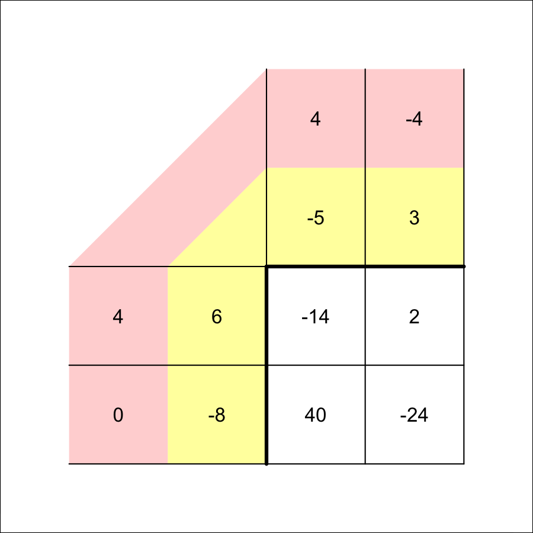

Matrices $A$ and $B$ are defined below.

$$A = \begin{bmatrix}
-7 & -2\\
0 & -8
\end{bmatrix}$$
$$B = \begin{bmatrix}
4 & -9\\
-5 & -2
\end{bmatrix}$$

Find the [product](https://en.wikipedia.org/wiki/Matrix_multiplication) $C=AB$.

$AB=$

We wish to do matrix multiplication:

$$\begin{bmatrix}
-7 & -2\\
0 & -8
\end{bmatrix}\begin{bmatrix}
4 & -9\\
-5 & -2
\end{bmatrix}$$

The product matrix has 2 rows and 2 columns.

To find the product matrix's value in row 1 and column 1, sum the products of corresponding elements of row 1 in matrix A and column 1 in matrix B.
$$C_{[1,1]}=(-7)(4)+(-2)(-5)=-18$$

To find the product matrix's value in row 1 and column 2, sum the products of corresponding elements of row 1 in matrix A and column 2 in matrix B.
$$C_{[1,2]}=(-7)(-9)+(-2)(-2)=67$$

To find the product matrix's value in row 2 and column 1, sum the products of corresponding elements of row 2 in matrix A and column 1 in matrix B.
$$C_{[2,1]}=(0)(4)+(-8)(-5)=40$$

To find the product matrix's value in row 2 and column 2, sum the products of corresponding elements of row 2 in matrix A and column 2 in matrix B.
$$C_{[2,2]}=(0)(-9)+(-8)(-2)=16$$

All of that work leads to the answer:

$$C = AB = \begin{bmatrix}
-18 & 67\\
40 & 16
\end{bmatrix}$$

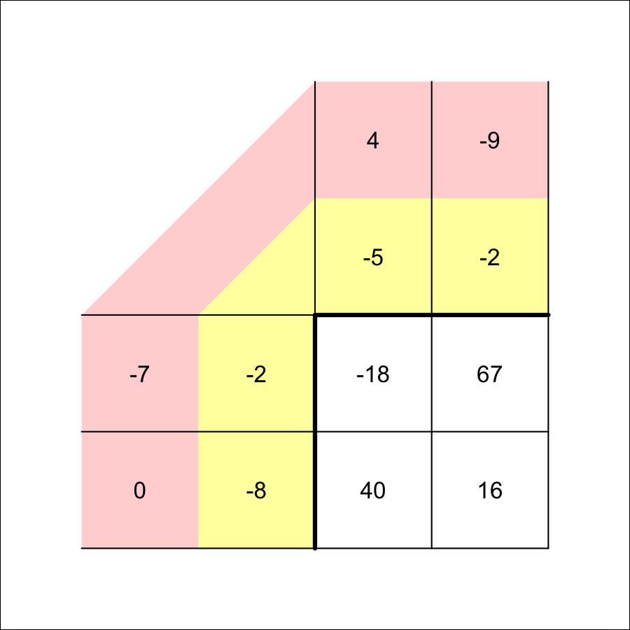

Matrices $A$ and $B$ are defined below.

$$A = \begin{bmatrix}
9 & 2\\
-6 & -4
\end{bmatrix}$$
$$B = \begin{bmatrix}
-4 & 8\\
7 & 5
\end{bmatrix}$$

Find the [product](https://en.wikipedia.org/wiki/Matrix_multiplication) $C=AB$.

$AB=$

We wish to do matrix multiplication:

$$\begin{bmatrix}
9 & 2\\
-6 & -4
\end{bmatrix}\begin{bmatrix}
-4 & 8\\
7 & 5
\end{bmatrix}$$

The product matrix has 2 rows and 2 columns.

To find the product matrix's value in row 1 and column 1, sum the products of corresponding elements of row 1 in matrix A and column 1 in matrix B.
$$C_{[1,1]}=(9)(-4)+(2)(7)=-22$$

To find the product matrix's value in row 1 and column 2, sum the products of corresponding elements of row 1 in matrix A and column 2 in matrix B.
$$C_{[1,2]}=(9)(8)+(2)(5)=82$$

To find the product matrix's value in row 2 and column 1, sum the products of corresponding elements of row 2 in matrix A and column 1 in matrix B.
$$C_{[2,1]}=(-6)(-4)+(-4)(7)=-4$$

To find the product matrix's value in row 2 and column 2, sum the products of corresponding elements of row 2 in matrix A and column 2 in matrix B.
$$C_{[2,2]}=(-6)(8)+(-4)(5)=-68$$

All of that work leads to the answer:

$$C = AB = \begin{bmatrix}
-22 & 82\\
-4 & -68
\end{bmatrix}$$

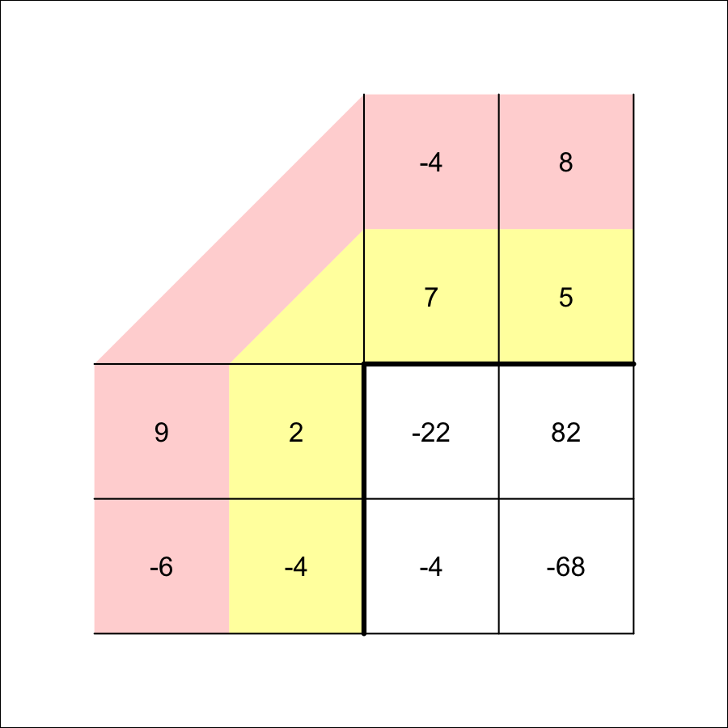

Matrices $A$ and $B$ are defined below.

$$A = \begin{bmatrix}
1 & 3\\
4 & 0
\end{bmatrix}$$
$$B = \begin{bmatrix}
-6 & -6\\
-4 & 0
\end{bmatrix}$$

Find the [product](https://en.wikipedia.org/wiki/Matrix_multiplication) $C=AB$.

$AB=$

We wish to do matrix multiplication:

$$\begin{bmatrix}
1 & 3\\
4 & 0
\end{bmatrix}\begin{bmatrix}
-6 & -6\\
-4 & 0
\end{bmatrix}$$

The product matrix has 2 rows and 2 columns.

To find the product matrix's value in row 1 and column 1, sum the products of corresponding elements of row 1 in matrix A and column 1 in matrix B.
$$C_{[1,1]}=(1)(-6)+(3)(-4)=-18$$

To find the product matrix's value in row 1 and column 2, sum the products of corresponding elements of row 1 in matrix A and column 2 in matrix B.
$$C_{[1,2]}=(1)(-6)+(3)(0)=-6$$

To find the product matrix's value in row 2 and column 1, sum the products of corresponding elements of row 2 in matrix A and column 1 in matrix B.
$$C_{[2,1]}=(4)(-6)+(0)(-4)=-24$$

To find the product matrix's value in row 2 and column 2, sum the products of corresponding elements of row 2 in matrix A and column 2 in matrix B.
$$C_{[2,2]}=(4)(-6)+(0)(0)=-24$$

All of that work leads to the answer:

$$C = AB = \begin{bmatrix}
-18 & -6\\
-24 & -24
\end{bmatrix}$$

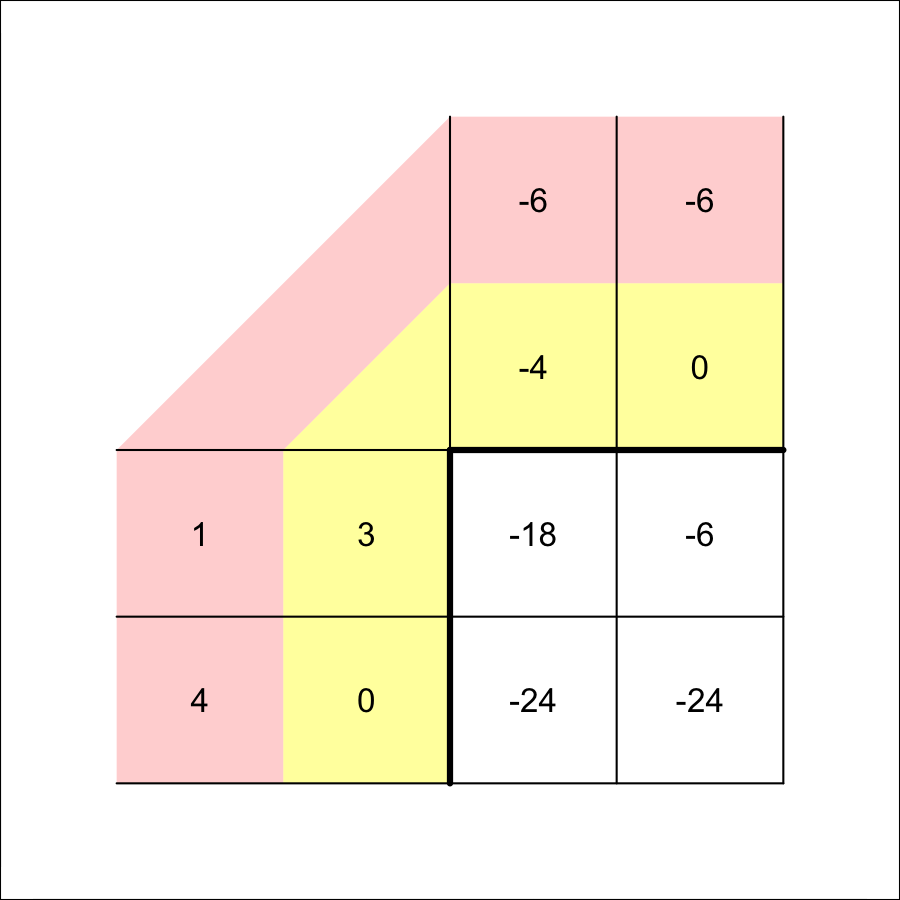

Matrices $A$ and $B$ are defined below.

$$A = \begin{bmatrix}
-1 & 1\\
5 & 9
\end{bmatrix}$$
$$B = \begin{bmatrix}
-1 & 9\\
-9 & 5
\end{bmatrix}$$

Find the [product](https://en.wikipedia.org/wiki/Matrix_multiplication) $C=AB$.

$AB=$

We wish to do matrix multiplication:

$$\begin{bmatrix}
-1 & 1\\
5 & 9
\end{bmatrix}\begin{bmatrix}
-1 & 9\\
-9 & 5
\end{bmatrix}$$

The product matrix has 2 rows and 2 columns.

To find the product matrix's value in row 1 and column 1, sum the products of corresponding elements of row 1 in matrix A and column 1 in matrix B.
$$C_{[1,1]}=(-1)(-1)+(1)(-9)=-8$$

To find the product matrix's value in row 1 and column 2, sum the products of corresponding elements of row 1 in matrix A and column 2 in matrix B.
$$C_{[1,2]}=(-1)(9)+(1)(5)=-4$$

To find the product matrix's value in row 2 and column 1, sum the products of corresponding elements of row 2 in matrix A and column 1 in matrix B.
$$C_{[2,1]}=(5)(-1)+(9)(-9)=-86$$

To find the product matrix's value in row 2 and column 2, sum the products of corresponding elements of row 2 in matrix A and column 2 in matrix B.
$$C_{[2,2]}=(5)(9)+(9)(5)=90$$

All of that work leads to the answer:

$$C = AB = \begin{bmatrix}
-8 & -4\\
-86 & 90
\end{bmatrix}$$

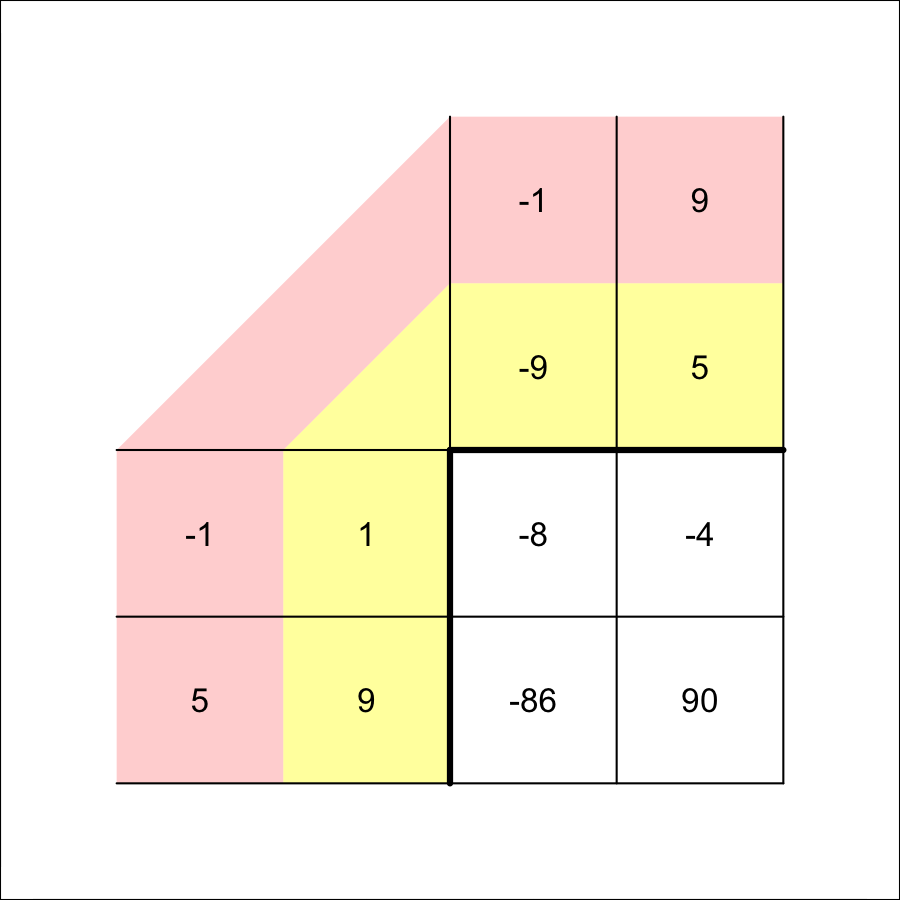

Matrices $A$ and $B$ are defined below.

$$A = \begin{bmatrix}
0 & 0\\
-6 & -9
\end{bmatrix}$$
$$B = \begin{bmatrix}
-7 & -7\\
-4 & 1
\end{bmatrix}$$

Find the [product](https://en.wikipedia.org/wiki/Matrix_multiplication) $C=AB$.

$AB=$

We wish to do matrix multiplication:

$$\begin{bmatrix}
0 & 0\\
-6 & -9
\end{bmatrix}\begin{bmatrix}
-7 & -7\\
-4 & 1
\end{bmatrix}$$

The product matrix has 2 rows and 2 columns.

To find the product matrix's value in row 1 and column 1, sum the products of corresponding elements of row 1 in matrix A and column 1 in matrix B.
$$C_{[1,1]}=(0)(-7)+(0)(-4)=0$$

To find the product matrix's value in row 1 and column 2, sum the products of corresponding elements of row 1 in matrix A and column 2 in matrix B.
$$C_{[1,2]}=(0)(-7)+(0)(1)=0$$

To find the product matrix's value in row 2 and column 1, sum the products of corresponding elements of row 2 in matrix A and column 1 in matrix B.
$$C_{[2,1]}=(-6)(-7)+(-9)(-4)=78$$

To find the product matrix's value in row 2 and column 2, sum the products of corresponding elements of row 2 in matrix A and column 2 in matrix B.
$$C_{[2,2]}=(-6)(-7)+(-9)(1)=33$$

All of that work leads to the answer:

$$C = AB = \begin{bmatrix}
0 & 0\\
78 & 33
\end{bmatrix}$$

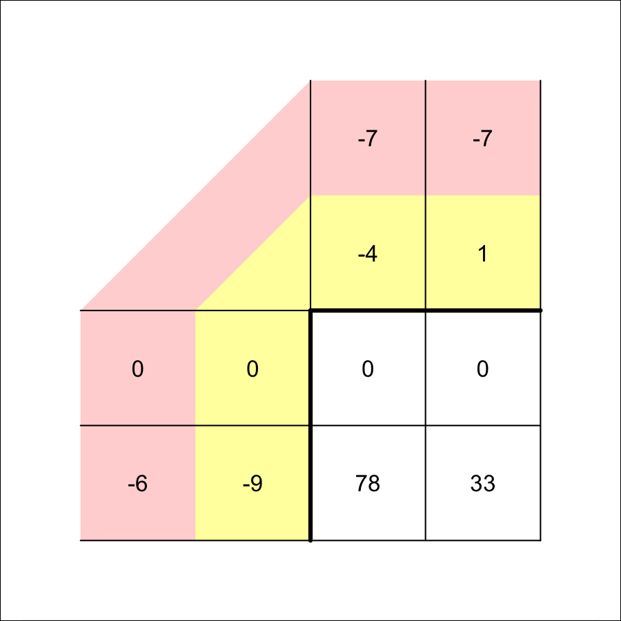

Matrices $A$ and $B$ are defined below.

$$A = \begin{bmatrix}
-6 & -2\\
-8 & -7
\end{bmatrix}$$
$$B = \begin{bmatrix}
-7 & -4\\
-4 & -4
\end{bmatrix}$$

Find the [product](https://en.wikipedia.org/wiki/Matrix_multiplication) $C=AB$.

$AB=$

We wish to do matrix multiplication:

$$\begin{bmatrix}
-6 & -2\\
-8 & -7
\end{bmatrix}\begin{bmatrix}
-7 & -4\\
-4 & -4
\end{bmatrix}$$

The product matrix has 2 rows and 2 columns.

To find the product matrix's value in row 1 and column 1, sum the products of corresponding elements of row 1 in matrix A and column 1 in matrix B.
$$C_{[1,1]}=(-6)(-7)+(-2)(-4)=50$$

To find the product matrix's value in row 1 and column 2, sum the products of corresponding elements of row 1 in matrix A and column 2 in matrix B.
$$C_{[1,2]}=(-6)(-4)+(-2)(-4)=32$$

To find the product matrix's value in row 2 and column 1, sum the products of corresponding elements of row 2 in matrix A and column 1 in matrix B.
$$C_{[2,1]}=(-8)(-7)+(-7)(-4)=84$$

To find the product matrix's value in row 2 and column 2, sum the products of corresponding elements of row 2 in matrix A and column 2 in matrix B.
$$C_{[2,2]}=(-8)(-4)+(-7)(-4)=60$$

All of that work leads to the answer:

$$C = AB = \begin{bmatrix}
50 & 32\\
84 & 60
\end{bmatrix}$$

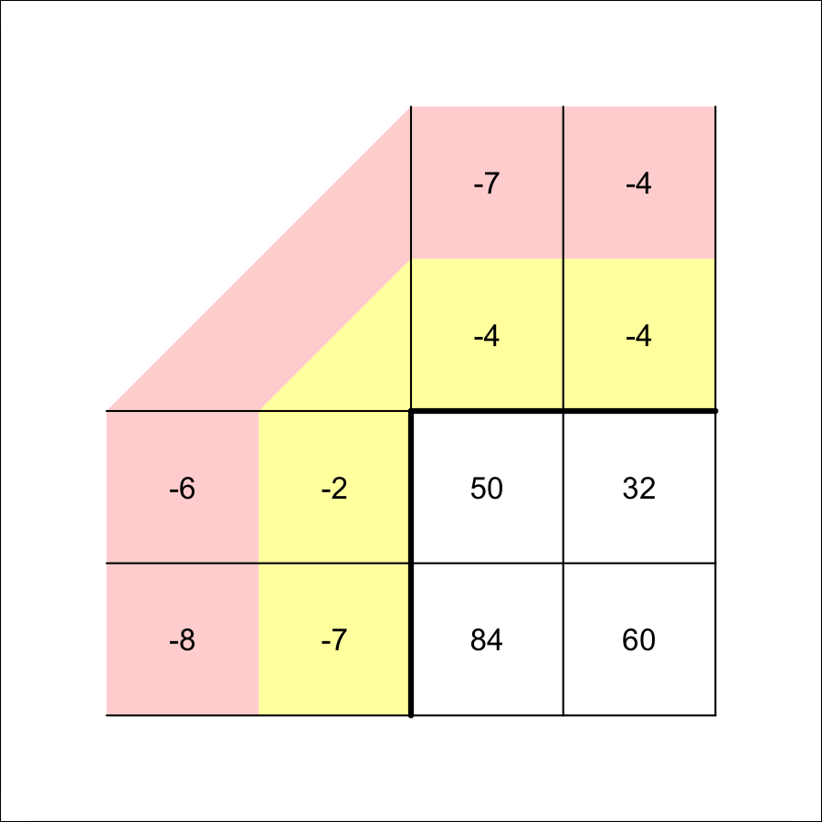

Matrices $A$ and $B$ are defined below.

$$A = \begin{bmatrix}
-8 & -9\\
-3 & -5
\end{bmatrix}$$
$$B = \begin{bmatrix}
7 & -6\\
-3 & 4
\end{bmatrix}$$

Find the [product](https://en.wikipedia.org/wiki/Matrix_multiplication) $C=AB$.

$AB=$

We wish to do matrix multiplication:

$$\begin{bmatrix}
-8 & -9\\
-3 & -5
\end{bmatrix}\begin{bmatrix}
7 & -6\\
-3 & 4
\end{bmatrix}$$

The product matrix has 2 rows and 2 columns.

To find the product matrix's value in row 1 and column 1, sum the products of corresponding elements of row 1 in matrix A and column 1 in matrix B.
$$C_{[1,1]}=(-8)(7)+(-9)(-3)=-29$$

To find the product matrix's value in row 1 and column 2, sum the products of corresponding elements of row 1 in matrix A and column 2 in matrix B.
$$C_{[1,2]}=(-8)(-6)+(-9)(4)=12$$

To find the product matrix's value in row 2 and column 1, sum the products of corresponding elements of row 2 in matrix A and column 1 in matrix B.
$$C_{[2,1]}=(-3)(7)+(-5)(-3)=-6$$

To find the product matrix's value in row 2 and column 2, sum the products of corresponding elements of row 2 in matrix A and column 2 in matrix B.
$$C_{[2,2]}=(-3)(-6)+(-5)(4)=-2$$

All of that work leads to the answer:

$$C = AB = \begin{bmatrix}
-29 & 12\\
-6 & -2
\end{bmatrix}$$

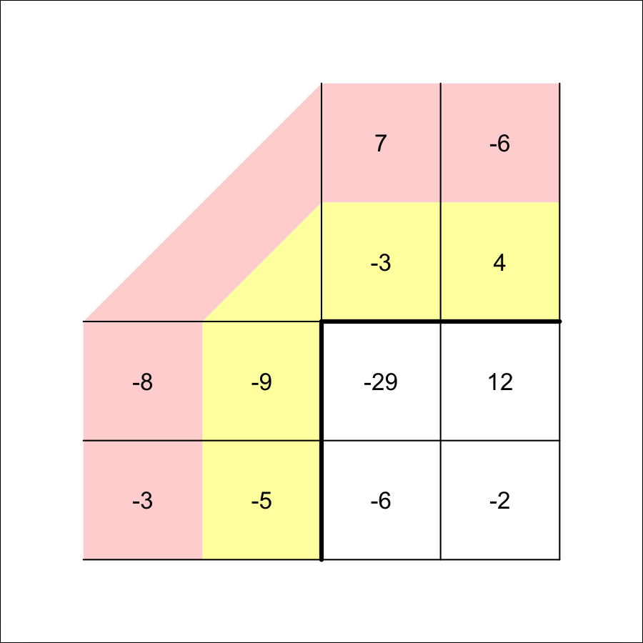

Matrices $A$ and $B$ are defined below.

$$A = \begin{bmatrix}
2 & 7\\
-7 & -4
\end{bmatrix}$$
$$B = \begin{bmatrix}
-8 & 3\\
8 & 9
\end{bmatrix}$$

Find the [product](https://en.wikipedia.org/wiki/Matrix_multiplication) $C=AB$.

$AB=$

We wish to do matrix multiplication:

$$\begin{bmatrix}
2 & 7\\
-7 & -4
\end{bmatrix}\begin{bmatrix}
-8 & 3\\
8 & 9
\end{bmatrix}$$

The product matrix has 2 rows and 2 columns.

To find the product matrix's value in row 1 and column 1, sum the products of corresponding elements of row 1 in matrix A and column 1 in matrix B.
$$C_{[1,1]}=(2)(-8)+(7)(8)=40$$

To find the product matrix's value in row 1 and column 2, sum the products of corresponding elements of row 1 in matrix A and column 2 in matrix B.
$$C_{[1,2]}=(2)(3)+(7)(9)=69$$

To find the product matrix's value in row 2 and column 1, sum the products of corresponding elements of row 2 in matrix A and column 1 in matrix B.
$$C_{[2,1]}=(-7)(-8)+(-4)(8)=24$$

To find the product matrix's value in row 2 and column 2, sum the products of corresponding elements of row 2 in matrix A and column 2 in matrix B.
$$C_{[2,2]}=(-7)(3)+(-4)(9)=-57$$

All of that work leads to the answer:

$$C = AB = \begin{bmatrix}
40 & 69\\
24 & -57
\end{bmatrix}$$

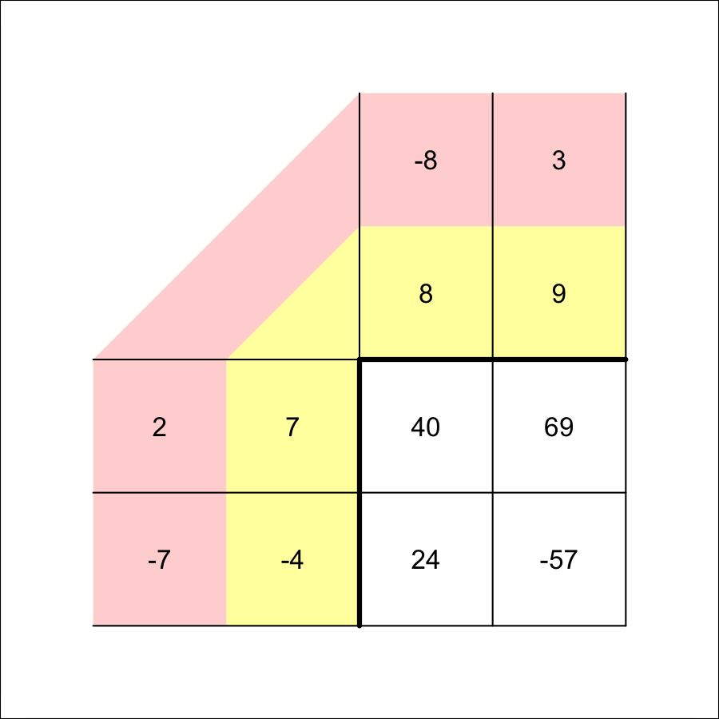

Matrices $A$ and $B$ are defined below.

$$A = \begin{bmatrix}
-9 & 2\\
3 & -2
\end{bmatrix}$$
$$B = \begin{bmatrix}
9 & 2\\
3 & -8
\end{bmatrix}$$

Find the [product](https://en.wikipedia.org/wiki/Matrix_multiplication) $C=AB$.

$AB=$

We wish to do matrix multiplication:

$$\begin{bmatrix}
-9 & 2\\
3 & -2
\end{bmatrix}\begin{bmatrix}
9 & 2\\
3 & -8
\end{bmatrix}$$

The product matrix has 2 rows and 2 columns.

To find the product matrix's value in row 1 and column 1, sum the products of corresponding elements of row 1 in matrix A and column 1 in matrix B.
$$C_{[1,1]}=(-9)(9)+(2)(3)=-75$$

To find the product matrix's value in row 1 and column 2, sum the products of corresponding elements of row 1 in matrix A and column 2 in matrix B.
$$C_{[1,2]}=(-9)(2)+(2)(-8)=-34$$

To find the product matrix's value in row 2 and column 1, sum the products of corresponding elements of row 2 in matrix A and column 1 in matrix B.
$$C_{[2,1]}=(3)(9)+(-2)(3)=21$$

To find the product matrix's value in row 2 and column 2, sum the products of corresponding elements of row 2 in matrix A and column 2 in matrix B.
$$C_{[2,2]}=(3)(2)+(-2)(-8)=22$$

All of that work leads to the answer:

$$C = AB = \begin{bmatrix}
-75 & -34\\
21 & 22
\end{bmatrix}$$

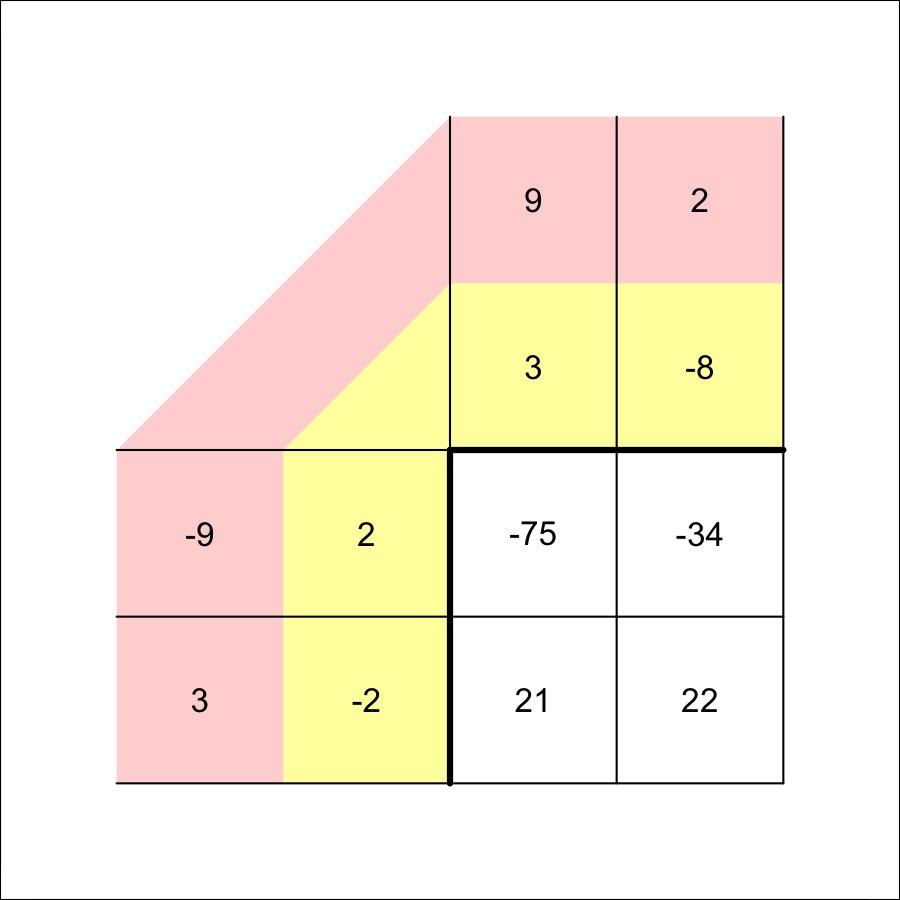

Matrices $A$ and $B$ are defined below.

$$A = \begin{bmatrix}
5 & 3\\
8 & -5
\end{bmatrix}$$
$$B = \begin{bmatrix}
-7 & 9\\
-2 & -1
\end{bmatrix}$$

Find the [product](https://en.wikipedia.org/wiki/Matrix_multiplication) $C=AB$.

$AB=$

We wish to do matrix multiplication:

$$\begin{bmatrix}
5 & 3\\
8 & -5
\end{bmatrix}\begin{bmatrix}
-7 & 9\\
-2 & -1
\end{bmatrix}$$

The product matrix has 2 rows and 2 columns.

To find the product matrix's value in row 1 and column 1, sum the products of corresponding elements of row 1 in matrix A and column 1 in matrix B.
$$C_{[1,1]}=(5)(-7)+(3)(-2)=-41$$

To find the product matrix's value in row 1 and column 2, sum the products of corresponding elements of row 1 in matrix A and column 2 in matrix B.
$$C_{[1,2]}=(5)(9)+(3)(-1)=42$$

To find the product matrix's value in row 2 and column 1, sum the products of corresponding elements of row 2 in matrix A and column 1 in matrix B.
$$C_{[2,1]}=(8)(-7)+(-5)(-2)=-46$$

To find the product matrix's value in row 2 and column 2, sum the products of corresponding elements of row 2 in matrix A and column 2 in matrix B.
$$C_{[2,2]}=(8)(9)+(-5)(-1)=77$$

All of that work leads to the answer:

$$C = AB = \begin{bmatrix}
-41 & 42\\
-46 & 77
\end{bmatrix}$$

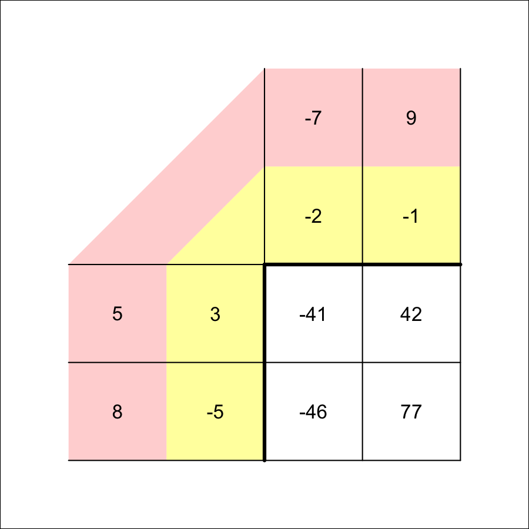

Matrices $A$ and $B$ are defined below.

$$A = \begin{bmatrix}
5 & -7\\
-3 & -6
\end{bmatrix}$$
$$B = \begin{bmatrix}
0 & 4\\
4 & -4
\end{bmatrix}$$

Find the [product](https://en.wikipedia.org/wiki/Matrix_multiplication) $C=AB$.

$AB=$

We wish to do matrix multiplication:

$$\begin{bmatrix}
5 & -7\\
-3 & -6
\end{bmatrix}\begin{bmatrix}
0 & 4\\
4 & -4
\end{bmatrix}$$

The product matrix has 2 rows and 2 columns.

To find the product matrix's value in row 1 and column 1, sum the products of corresponding elements of row 1 in matrix A and column 1 in matrix B.
$$C_{[1,1]}=(5)(0)+(-7)(4)=-28$$

To find the product matrix's value in row 1 and column 2, sum the products of corresponding elements of row 1 in matrix A and column 2 in matrix B.
$$C_{[1,2]}=(5)(4)+(-7)(-4)=48$$

To find the product matrix's value in row 2 and column 1, sum the products of corresponding elements of row 2 in matrix A and column 1 in matrix B.
$$C_{[2,1]}=(-3)(0)+(-6)(4)=-24$$

To find the product matrix's value in row 2 and column 2, sum the products of corresponding elements of row 2 in matrix A and column 2 in matrix B.
$$C_{[2,2]}=(-3)(4)+(-6)(-4)=12$$

All of that work leads to the answer:

$$C = AB = \begin{bmatrix}
-28 & 48\\
-24 & 12
\end{bmatrix}$$

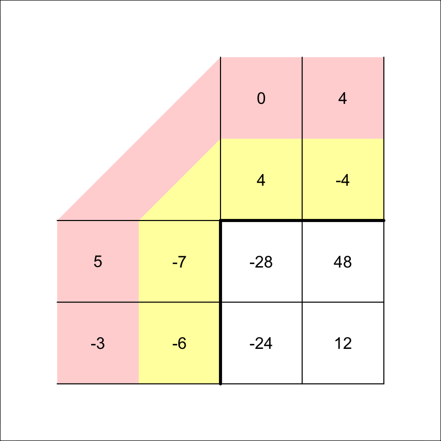

Matrices $A$ and $B$ are defined below.

$$A = \begin{bmatrix}
2 & -3\\
4 & -1
\end{bmatrix}$$
$$B = \begin{bmatrix}
7 & 0\\
-8 & 2
\end{bmatrix}$$

Find the [product](https://en.wikipedia.org/wiki/Matrix_multiplication) $C=AB$.

$AB=$

We wish to do matrix multiplication:

$$\begin{bmatrix}
2 & -3\\
4 & -1
\end{bmatrix}\begin{bmatrix}
7 & 0\\
-8 & 2
\end{bmatrix}$$

The product matrix has 2 rows and 2 columns.

To find the product matrix's value in row 1 and column 1, sum the products of corresponding elements of row 1 in matrix A and column 1 in matrix B.
$$C_{[1,1]}=(2)(7)+(-3)(-8)=38$$

To find the product matrix's value in row 1 and column 2, sum the products of corresponding elements of row 1 in matrix A and column 2 in matrix B.
$$C_{[1,2]}=(2)(0)+(-3)(2)=-6$$

To find the product matrix's value in row 2 and column 1, sum the products of corresponding elements of row 2 in matrix A and column 1 in matrix B.
$$C_{[2,1]}=(4)(7)+(-1)(-8)=36$$

To find the product matrix's value in row 2 and column 2, sum the products of corresponding elements of row 2 in matrix A and column 2 in matrix B.
$$C_{[2,2]}=(4)(0)+(-1)(2)=-2$$

All of that work leads to the answer:

$$C = AB = \begin{bmatrix}
38 & -6\\
36 & -2
\end{bmatrix}$$

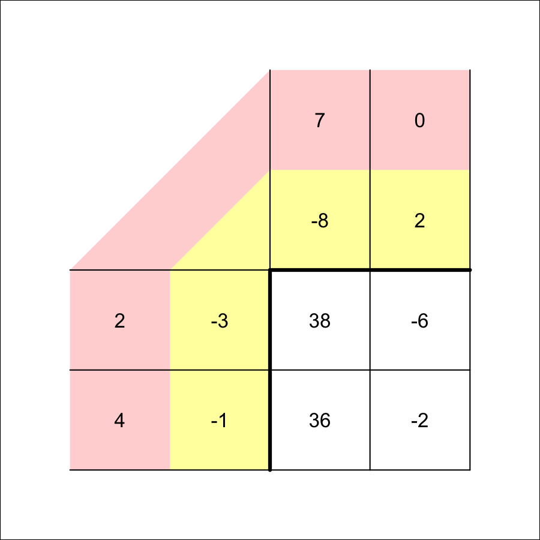

Matrices $A$ and $B$ are defined below.

$$A = \begin{bmatrix}
5 & -1\\
5 & 7
\end{bmatrix}$$
$$B = \begin{bmatrix}
2 & -6\\
7 & -9
\end{bmatrix}$$

Find the [product](https://en.wikipedia.org/wiki/Matrix_multiplication) $C=AB$.

$AB=$

We wish to do matrix multiplication:

$$\begin{bmatrix}
5 & -1\\
5 & 7
\end{bmatrix}\begin{bmatrix}
2 & -6\\
7 & -9
\end{bmatrix}$$

The product matrix has 2 rows and 2 columns.

To find the product matrix's value in row 1 and column 1, sum the products of corresponding elements of row 1 in matrix A and column 1 in matrix B.
$$C_{[1,1]}=(5)(2)+(-1)(7)=3$$

To find the product matrix's value in row 1 and column 2, sum the products of corresponding elements of row 1 in matrix A and column 2 in matrix B.
$$C_{[1,2]}=(5)(-6)+(-1)(-9)=-21$$

To find the product matrix's value in row 2 and column 1, sum the products of corresponding elements of row 2 in matrix A and column 1 in matrix B.
$$C_{[2,1]}=(5)(2)+(7)(7)=59$$

To find the product matrix's value in row 2 and column 2, sum the products of corresponding elements of row 2 in matrix A and column 2 in matrix B.
$$C_{[2,2]}=(5)(-6)+(7)(-9)=-93$$

All of that work leads to the answer:

$$C = AB = \begin{bmatrix}
3 & -21\\
59 & -93
\end{bmatrix}$$

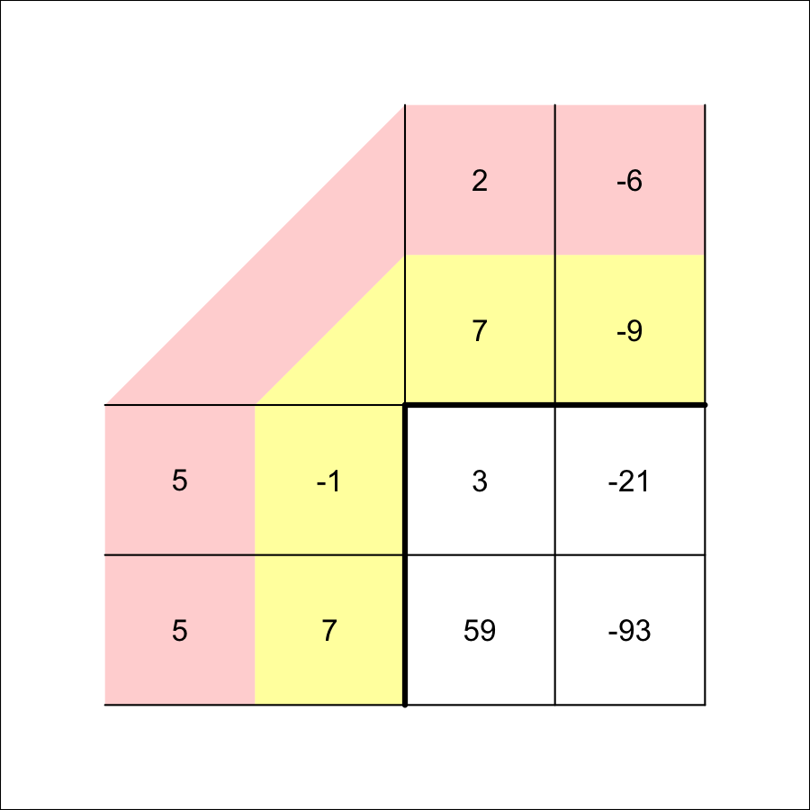

Matrices $A$ and $B$ are defined below.

$$A = \begin{bmatrix}
3 & -2\\
3 & -8
\end{bmatrix}$$
$$B = \begin{bmatrix}
8 & 7\\
9 & -8
\end{bmatrix}$$

Find the [product](https://en.wikipedia.org/wiki/Matrix_multiplication) $C=AB$.

$AB=$

We wish to do matrix multiplication:

$$\begin{bmatrix}
3 & -2\\
3 & -8
\end{bmatrix}\begin{bmatrix}
8 & 7\\
9 & -8
\end{bmatrix}$$

The product matrix has 2 rows and 2 columns.

To find the product matrix's value in row 1 and column 1, sum the products of corresponding elements of row 1 in matrix A and column 1 in matrix B.
$$C_{[1,1]}=(3)(8)+(-2)(9)=6$$

To find the product matrix's value in row 1 and column 2, sum the products of corresponding elements of row 1 in matrix A and column 2 in matrix B.
$$C_{[1,2]}=(3)(7)+(-2)(-8)=37$$

To find the product matrix's value in row 2 and column 1, sum the products of corresponding elements of row 2 in matrix A and column 1 in matrix B.
$$C_{[2,1]}=(3)(8)+(-8)(9)=-48$$

To find the product matrix's value in row 2 and column 2, sum the products of corresponding elements of row 2 in matrix A and column 2 in matrix B.
$$C_{[2,2]}=(3)(7)+(-8)(-8)=85$$

All of that work leads to the answer:

$$C = AB = \begin{bmatrix}
6 & 37\\
-48 & 85
\end{bmatrix}$$

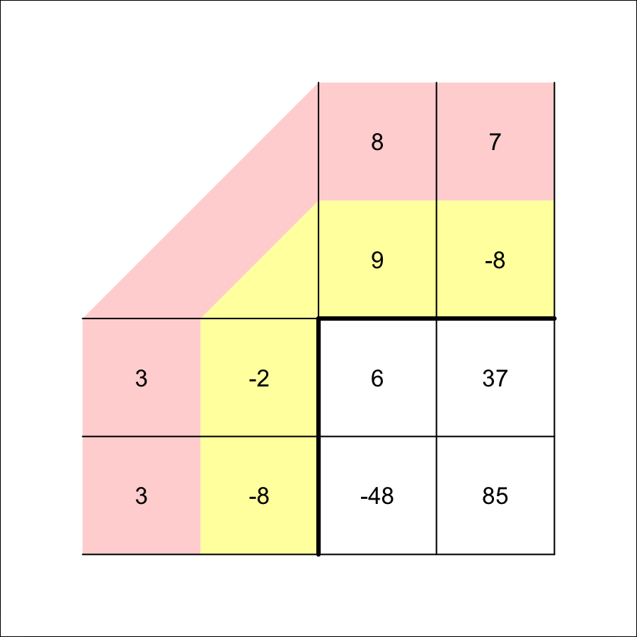

Matrices $A$ and $B$ are defined below.

$$A = \begin{bmatrix}
0 & -3\\
0 & -8
\end{bmatrix}$$
$$B = \begin{bmatrix}
1 & -5\\
6 & -5
\end{bmatrix}$$

Find the [product](https://en.wikipedia.org/wiki/Matrix_multiplication) $C=AB$.

$AB=$

We wish to do matrix multiplication:

$$\begin{bmatrix}
0 & -3\\
0 & -8
\end{bmatrix}\begin{bmatrix}
1 & -5\\
6 & -5
\end{bmatrix}$$

The product matrix has 2 rows and 2 columns.

To find the product matrix's value in row 1 and column 1, sum the products of corresponding elements of row 1 in matrix A and column 1 in matrix B.
$$C_{[1,1]}=(0)(1)+(-3)(6)=-18$$

To find the product matrix's value in row 1 and column 2, sum the products of corresponding elements of row 1 in matrix A and column 2 in matrix B.
$$C_{[1,2]}=(0)(-5)+(-3)(-5)=15$$

To find the product matrix's value in row 2 and column 1, sum the products of corresponding elements of row 2 in matrix A and column 1 in matrix B.
$$C_{[2,1]}=(0)(1)+(-8)(6)=-48$$

To find the product matrix's value in row 2 and column 2, sum the products of corresponding elements of row 2 in matrix A and column 2 in matrix B.
$$C_{[2,2]}=(0)(-5)+(-8)(-5)=40$$

All of that work leads to the answer:

$$C = AB = \begin{bmatrix}
-18 & 15\\
-48 & 40
\end{bmatrix}$$

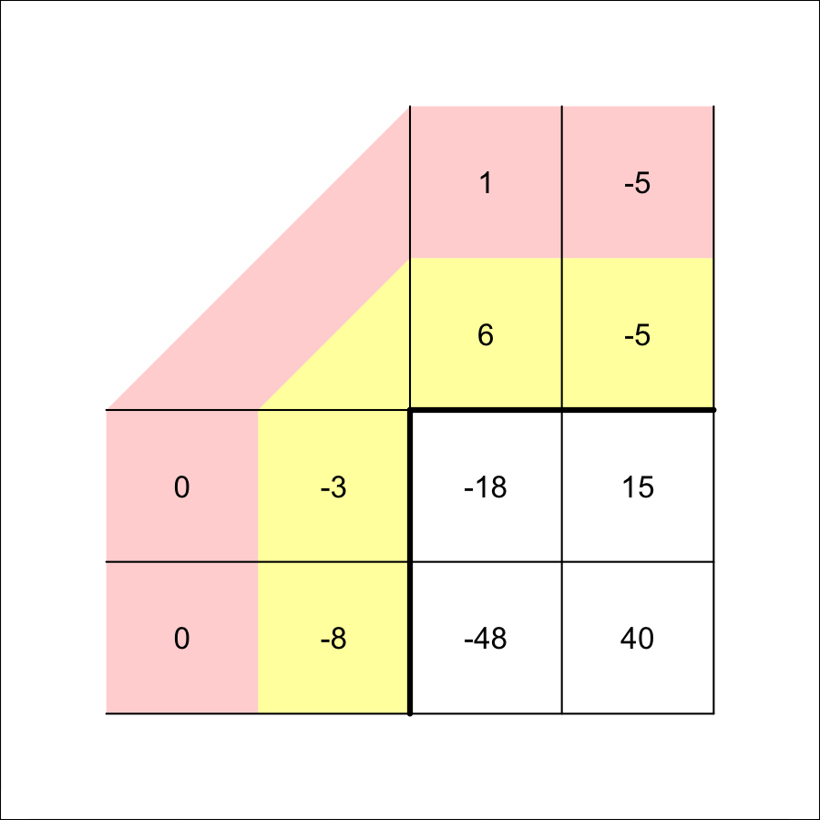

Matrices $A$ and $B$ are defined below.

$$A = \begin{bmatrix}
7 & 3\\
1 & 4
\end{bmatrix}$$
$$B = \begin{bmatrix}
-6 & -9\\
-4 & -3
\end{bmatrix}$$

Find the [product](https://en.wikipedia.org/wiki/Matrix_multiplication) $C=AB$.

$AB=$

We wish to do matrix multiplication:

$$\begin{bmatrix}
7 & 3\\
1 & 4
\end{bmatrix}\begin{bmatrix}
-6 & -9\\
-4 & -3
\end{bmatrix}$$

The product matrix has 2 rows and 2 columns.

To find the product matrix's value in row 1 and column 1, sum the products of corresponding elements of row 1 in matrix A and column 1 in matrix B.
$$C_{[1,1]}=(7)(-6)+(3)(-4)=-54$$

To find the product matrix's value in row 1 and column 2, sum the products of corresponding elements of row 1 in matrix A and column 2 in matrix B.
$$C_{[1,2]}=(7)(-9)+(3)(-3)=-72$$

To find the product matrix's value in row 2 and column 1, sum the products of corresponding elements of row 2 in matrix A and column 1 in matrix B.
$$C_{[2,1]}=(1)(-6)+(4)(-4)=-22$$

To find the product matrix's value in row 2 and column 2, sum the products of corresponding elements of row 2 in matrix A and column 2 in matrix B.
$$C_{[2,2]}=(1)(-9)+(4)(-3)=-21$$

All of that work leads to the answer:

$$C = AB = \begin{bmatrix}
-54 & -72\\
-22 & -21
\end{bmatrix}$$

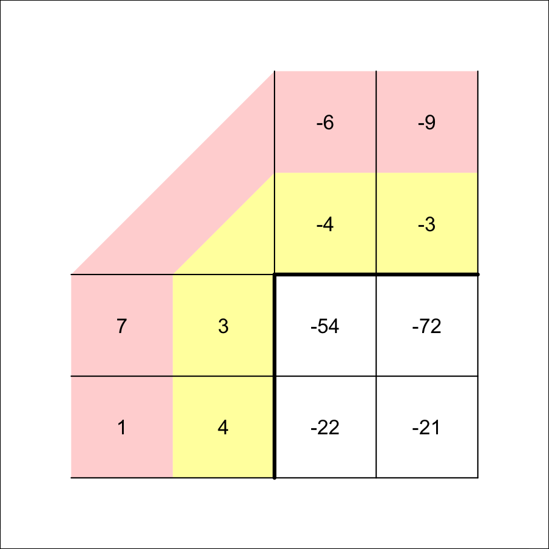

Matrices $A$ and $B$ are defined below.

$$A = \begin{bmatrix}
2 & -9\\
6 & 2
\end{bmatrix}$$
$$B = \begin{bmatrix}
9 & -1\\
4 & -1
\end{bmatrix}$$

Find the [product](https://en.wikipedia.org/wiki/Matrix_multiplication) $C=AB$.

$AB=$

We wish to do matrix multiplication:

$$\begin{bmatrix}
2 & -9\\
6 & 2
\end{bmatrix}\begin{bmatrix}
9 & -1\\
4 & -1
\end{bmatrix}$$

The product matrix has 2 rows and 2 columns.

To find the product matrix's value in row 1 and column 1, sum the products of corresponding elements of row 1 in matrix A and column 1 in matrix B.
$$C_{[1,1]}=(2)(9)+(-9)(4)=-18$$

To find the product matrix's value in row 1 and column 2, sum the products of corresponding elements of row 1 in matrix A and column 2 in matrix B.
$$C_{[1,2]}=(2)(-1)+(-9)(-1)=7$$

To find the product matrix's value in row 2 and column 1, sum the products of corresponding elements of row 2 in matrix A and column 1 in matrix B.
$$C_{[2,1]}=(6)(9)+(2)(4)=62$$

To find the product matrix's value in row 2 and column 2, sum the products of corresponding elements of row 2 in matrix A and column 2 in matrix B.
$$C_{[2,2]}=(6)(-1)+(2)(-1)=-8$$

All of that work leads to the answer:

$$C = AB = \begin{bmatrix}
-18 & 7\\
62 & -8
\end{bmatrix}$$

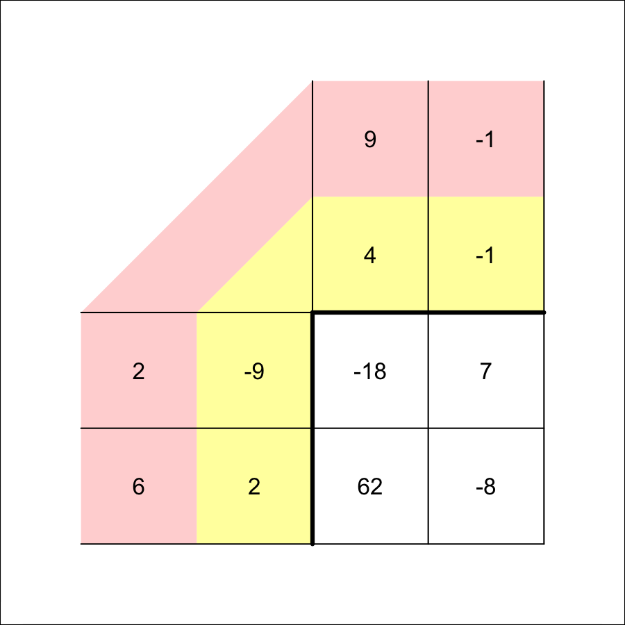

Matrices $A$ and $B$ are defined below.

$$A = \begin{bmatrix}
-4 & 1\\
-6 & 5
\end{bmatrix}$$
$$B = \begin{bmatrix}
9 & -4\\
6 & 4
\end{bmatrix}$$

Find the [product](https://en.wikipedia.org/wiki/Matrix_multiplication) $C=AB$.

$AB=$

We wish to do matrix multiplication:

$$\begin{bmatrix}
-4 & 1\\
-6 & 5
\end{bmatrix}\begin{bmatrix}
9 & -4\\
6 & 4
\end{bmatrix}$$

The product matrix has 2 rows and 2 columns.

To find the product matrix's value in row 1 and column 1, sum the products of corresponding elements of row 1 in matrix A and column 1 in matrix B.
$$C_{[1,1]}=(-4)(9)+(1)(6)=-30$$

To find the product matrix's value in row 1 and column 2, sum the products of corresponding elements of row 1 in matrix A and column 2 in matrix B.
$$C_{[1,2]}=(-4)(-4)+(1)(4)=20$$

To find the product matrix's value in row 2 and column 1, sum the products of corresponding elements of row 2 in matrix A and column 1 in matrix B.
$$C_{[2,1]}=(-6)(9)+(5)(6)=-24$$

To find the product matrix's value in row 2 and column 2, sum the products of corresponding elements of row 2 in matrix A and column 2 in matrix B.
$$C_{[2,2]}=(-6)(-4)+(5)(4)=44$$

All of that work leads to the answer:

$$C = AB = \begin{bmatrix}
-30 & 20\\
-24 & 44
\end{bmatrix}$$

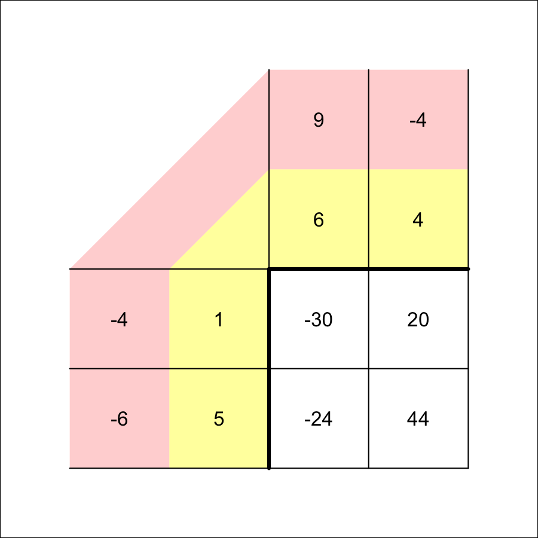

Matrices $A$ and $B$ are defined below.

$$A = \begin{bmatrix}
-6 & 9\\
-8 & 8
\end{bmatrix}$$
$$B = \begin{bmatrix}
4 & -3\\
5 & -8
\end{bmatrix}$$

Find the [product](https://en.wikipedia.org/wiki/Matrix_multiplication) $C=AB$.

$AB=$

We wish to do matrix multiplication:

$$\begin{bmatrix}
-6 & 9\\
-8 & 8
\end{bmatrix}\begin{bmatrix}
4 & -3\\
5 & -8
\end{bmatrix}$$

The product matrix has 2 rows and 2 columns.

To find the product matrix's value in row 1 and column 1, sum the products of corresponding elements of row 1 in matrix A and column 1 in matrix B.
$$C_{[1,1]}=(-6)(4)+(9)(5)=21$$

To find the product matrix's value in row 1 and column 2, sum the products of corresponding elements of row 1 in matrix A and column 2 in matrix B.
$$C_{[1,2]}=(-6)(-3)+(9)(-8)=-54$$

To find the product matrix's value in row 2 and column 1, sum the products of corresponding elements of row 2 in matrix A and column 1 in matrix B.
$$C_{[2,1]}=(-8)(4)+(8)(5)=8$$

To find the product matrix's value in row 2 and column 2, sum the products of corresponding elements of row 2 in matrix A and column 2 in matrix B.
$$C_{[2,2]}=(-8)(-3)+(8)(-8)=-40$$

All of that work leads to the answer:

$$C = AB = \begin{bmatrix}
21 & -54\\
8 & -40
\end{bmatrix}$$

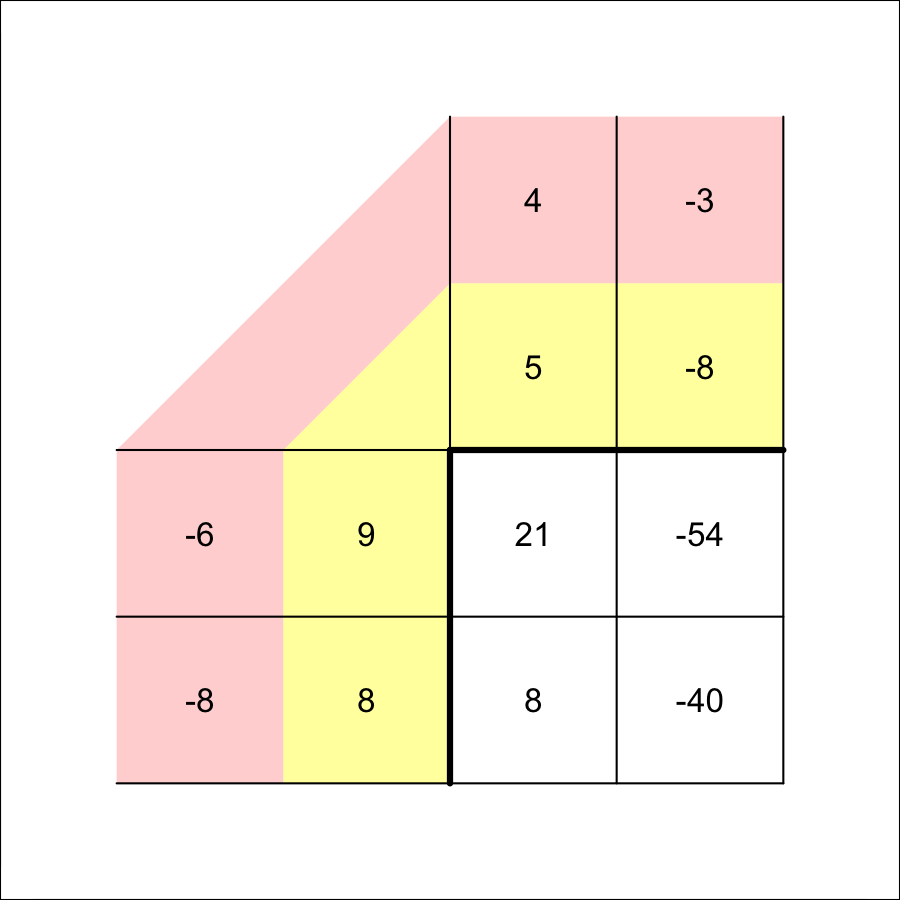

The figure below shows 7 polygons on a $10\times10$ grid. The grid is composed of 100 squares, each with an area of 1. Each polygon's area is labelled with an uppercase letter from $A$ to $G$.

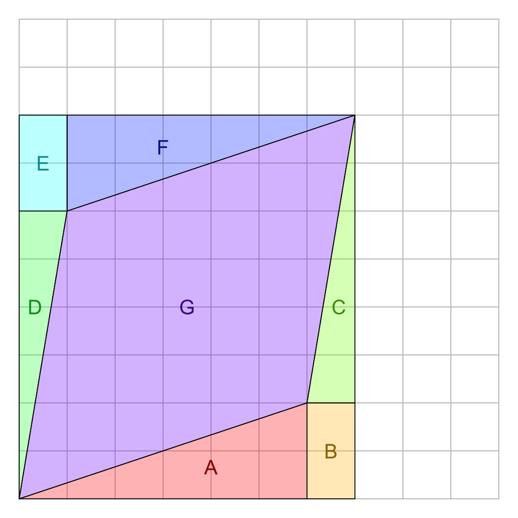

Find the areas of the triangles, rectangles, and parallelogram.

- $A=$
- $B=$
- $C=$
- $D=$
- $E=$
- $F=$
- $G=$
- Remember the area of a rectangle is width times height.
- Remember the area of a triangle is half of base times height.
  - For a right triangle, half the product of the legs.
- To find the area of the parallelogram, you can subtract all 6 other areas from the total area of the rectangle containing all 7 pieces.
- $a=6$
- $b=2$
- $c=3$
- $d=3$
- $e=2$
- $f=6$
- $g=34$

The figure below shows 7 polygons on a $10\times10$ grid. The grid is composed of 100 squares, each with an area of 1. Each polygon's area is labelled with an uppercase letter from $A$ to $G$.

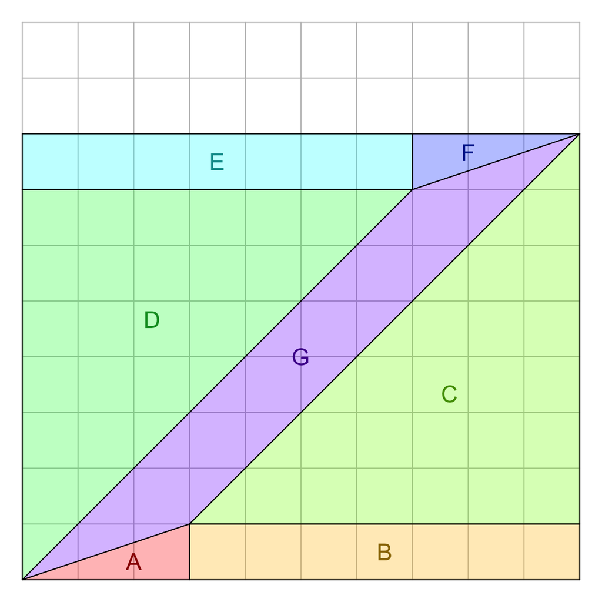

Find the areas of the triangles, rectangles, and parallelogram.

- $A=$
- $B=$
- $C=$
- $D=$
- $E=$
- $F=$
- $G=$
- Remember the area of a rectangle is width times height.
- Remember the area of a triangle is half of base times height.
  - For a right triangle, half the product of the legs.
- To find the area of the parallelogram, you can subtract all 6 other areas from the total area of the rectangle containing all 7 pieces.
- $a=1.5$
- $b=7$
- $c=24.5$
- $d=24.5$
- $e=7$
- $f=1.5$
- $g=14$

The figure below shows 7 polygons on a $10\times10$ grid. The grid is composed of 100 squares, each with an area of 1. Each polygon's area is labelled with an uppercase letter from $A$ to $G$.

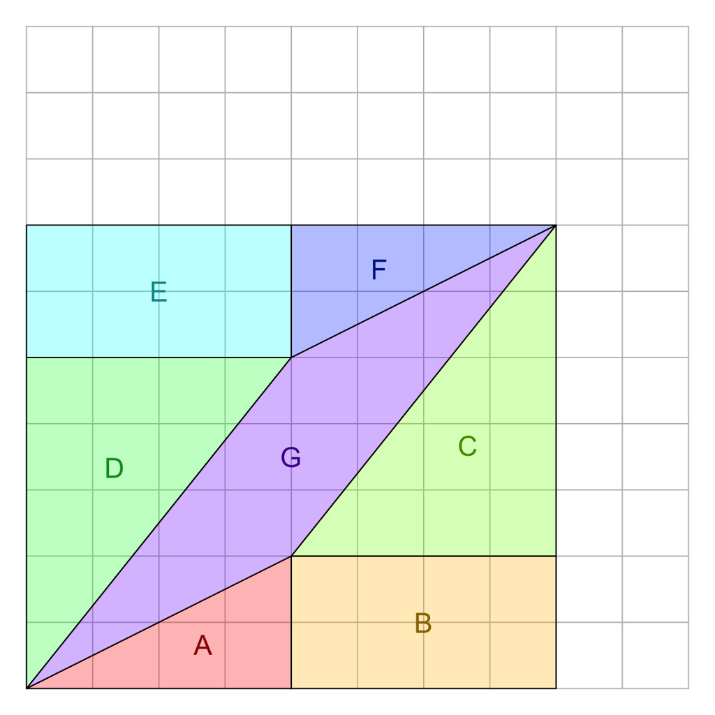

Find the areas of the triangles, rectangles, and parallelogram.

- $A=$
- $B=$
- $C=$
- $D=$
- $E=$
- $F=$
- $G=$
- Remember the area of a rectangle is width times height.
- Remember the area of a triangle is half of base times height.
  - For a right triangle, half the product of the legs.
- To find the area of the parallelogram, you can subtract all 6 other areas from the total area of the rectangle containing all 7 pieces.
- $a=4$
- $b=8$
- $c=10$
- $d=10$
- $e=8$
- $f=4$
- $g=12$

The figure below shows 7 polygons on a $10\times10$ grid. The grid is composed of 100 squares, each with an area of 1. Each polygon's area is labelled with an uppercase letter from $A$ to $G$.

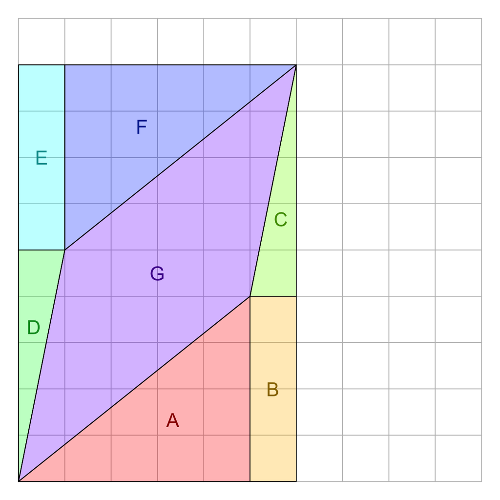

Find the areas of the triangles, rectangles, and parallelogram.

- $A=$
- $B=$
- $C=$
- $D=$
- $E=$
- $F=$
- $G=$
- Remember the area of a rectangle is width times height.
- Remember the area of a triangle is half of base times height.
  - For a right triangle, half the product of the legs.
- To find the area of the parallelogram, you can subtract all 6 other areas from the total area of the rectangle containing all 7 pieces.
- $a=10$
- $b=4$
- $c=2.5$
- $d=2.5$
- $e=4$
- $f=10$
- $g=21$

The figure below shows 7 polygons on a $10\times10$ grid. The grid is composed of 100 squares, each with an area of 1. Each polygon's area is labelled with an uppercase letter from $A$ to $G$.

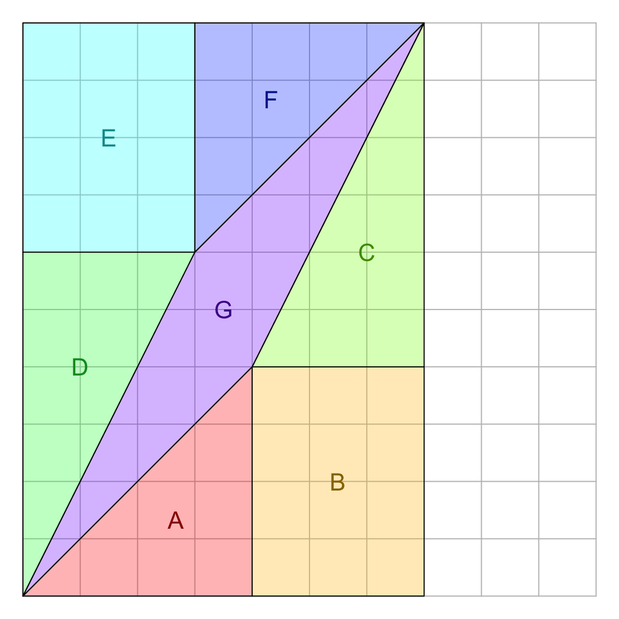

Find the areas of the triangles, rectangles, and parallelogram.

- $A=$
- $B=$
- $C=$
- $D=$
- $E=$
- $F=$
- $G=$
- Remember the area of a rectangle is width times height.
- Remember the area of a triangle is half of base times height.
  - For a right triangle, half the product of the legs.
- To find the area of the parallelogram, you can subtract all 6 other areas from the total area of the rectangle containing all 7 pieces.
- $a=8$
- $b=12$
- $c=9$
- $d=9$
- $e=12$
- $f=8$
- $g=12$

The figure below shows 7 polygons on a $10\times10$ grid. The grid is composed of 100 squares, each with an area of 1. Each polygon's area is labelled with an uppercase letter from $A$ to $G$.

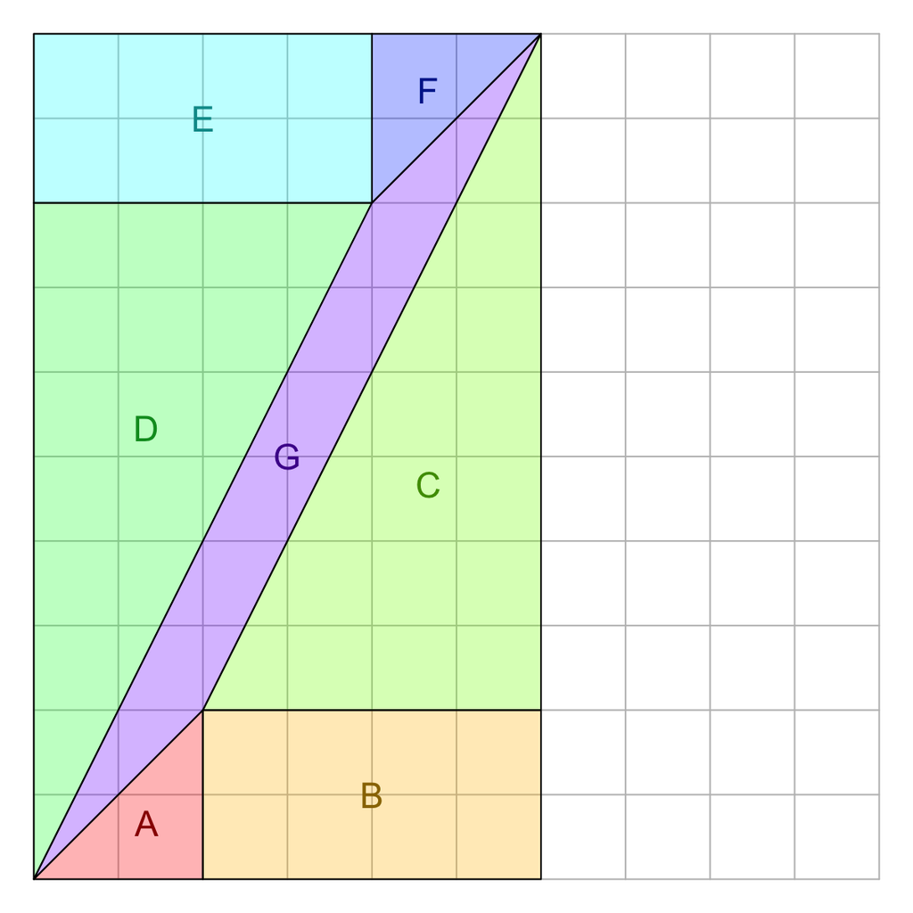

Find the areas of the triangles, rectangles, and parallelogram.

- $A=$
- $B=$
- $C=$
- $D=$
- $E=$
- $F=$
- $G=$
- Remember the area of a rectangle is width times height.
- Remember the area of a triangle is half of base times height.
  - For a right triangle, half the product of the legs.
- To find the area of the parallelogram, you can subtract all 6 other areas from the total area of the rectangle containing all 7 pieces.
- $a=2$
- $b=8$
- $c=16$
- $d=16$
- $e=8$
- $f=2$
- $g=8$

The figure below shows 7 polygons on a $10\times10$ grid. The grid is composed of 100 squares, each with an area of 1. Each polygon's area is labelled with an uppercase letter from $A$ to $G$.

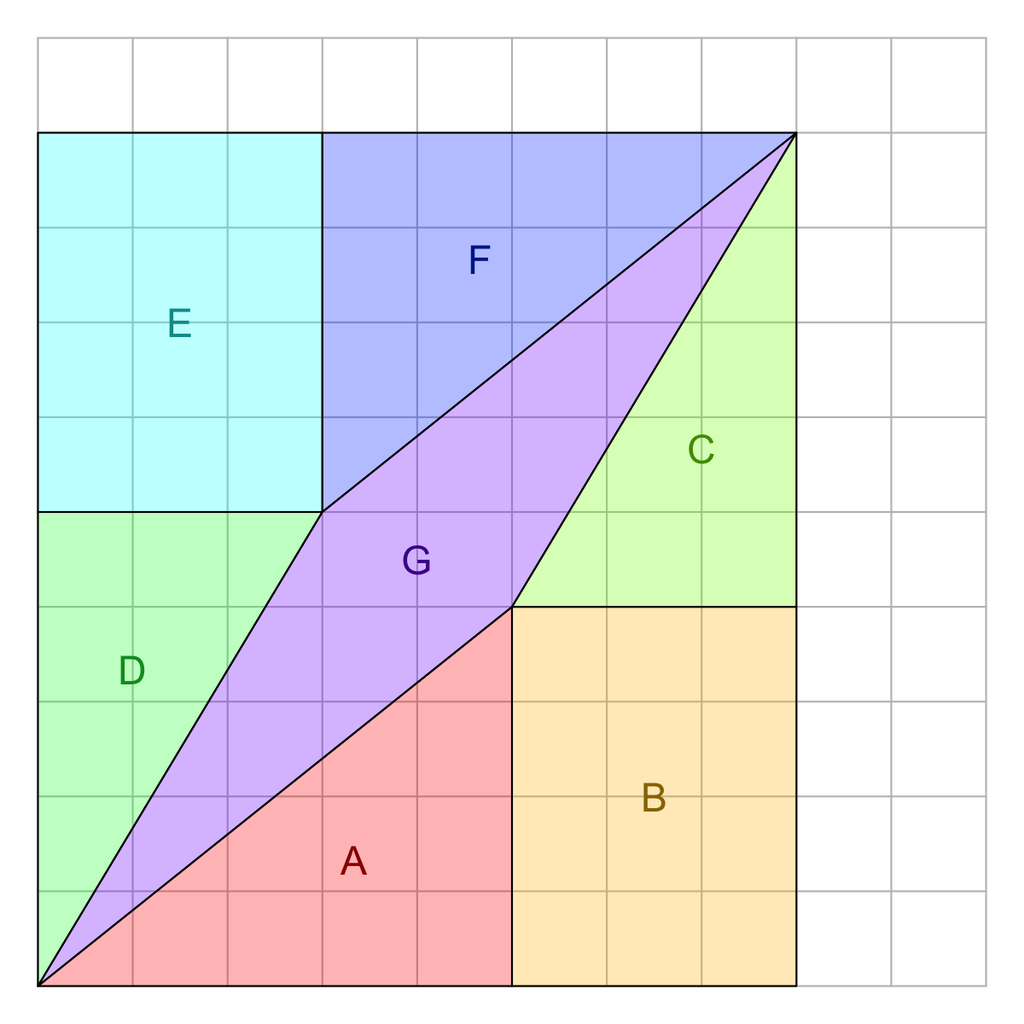

Find the areas of the triangles, rectangles, and parallelogram.

- $A=$
- $B=$
- $C=$
- $D=$
- $E=$
- $F=$
- $G=$
- Remember the area of a rectangle is width times height.
- Remember the area of a triangle is half of base times height.
  - For a right triangle, half the product of the legs.
- To find the area of the parallelogram, you can subtract all 6 other areas from the total area of the rectangle containing all 7 pieces.
- $a=10$
- $b=12$
- $c=7.5$
- $d=7.5$
- $e=12$
- $f=10$
- $g=13$

The figure below shows 7 polygons on a $10\times10$ grid. The grid is composed of 100 squares, each with an area of 1. Each polygon's area is labelled with an uppercase letter from $A$ to $G$.

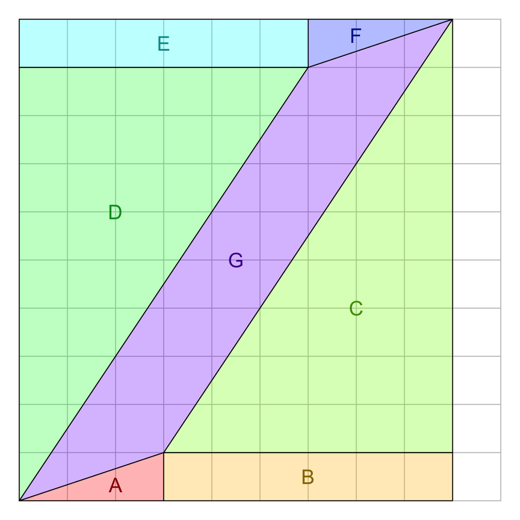

Find the areas of the triangles, rectangles, and parallelogram.

- $A=$
- $B=$
- $C=$
- $D=$
- $E=$
- $F=$
- $G=$
- Remember the area of a rectangle is width times height.
- Remember the area of a triangle is half of base times height.
  - For a right triangle, half the product of the legs.
- To find the area of the parallelogram, you can subtract all 6 other areas from the total area of the rectangle containing all 7 pieces.
- $a=1.5$
- $b=6$
- $c=27$
- $d=27$
- $e=6$
- $f=1.5$
- $g=21$

The figure below shows 7 polygons on a $10\times10$ grid. The grid is composed of 100 squares, each with an area of 1. Each polygon's area is labelled with an uppercase letter from $A$ to $G$.

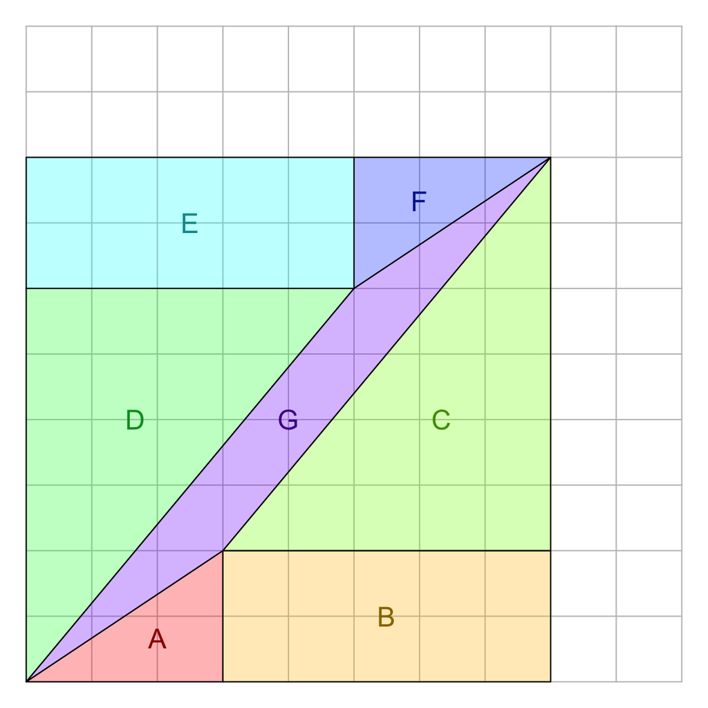

Find the areas of the triangles, rectangles, and parallelogram.

- $A=$
- $B=$
- $C=$
- $D=$
- $E=$
- $F=$
- $G=$
- Remember the area of a rectangle is width times height.
- Remember the area of a triangle is half of base times height.
  - For a right triangle, half the product of the legs.
- To find the area of the parallelogram, you can subtract all 6 other areas from the total area of the rectangle containing all 7 pieces.
- $a=3$
- $b=10$
- $c=15$
- $d=15$
- $e=10$
- $f=3$
- $g=8$

The figure below shows 7 polygons on a $10\times10$ grid. The grid is composed of 100 squares, each with an area of 1. Each polygon's area is labelled with an uppercase letter from $A$ to $G$.

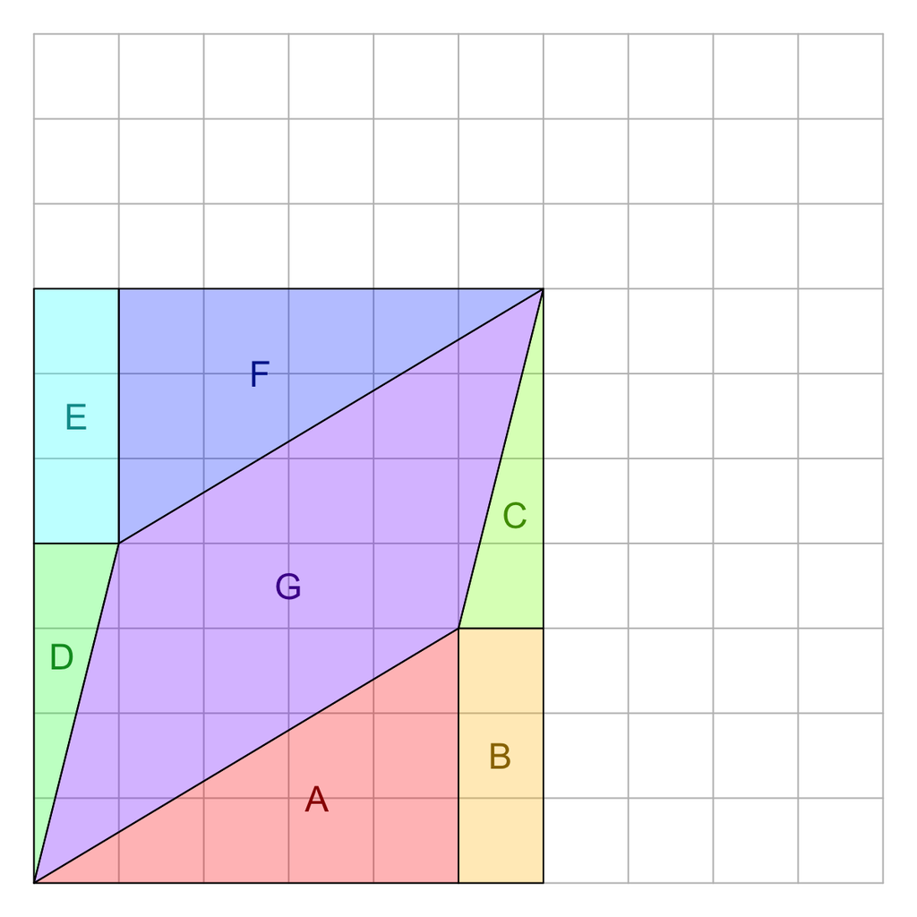

Find the areas of the triangles, rectangles, and parallelogram.

- $A=$
- $B=$
- $C=$
- $D=$
- $E=$
- $F=$
- $G=$
- Remember the area of a rectangle is width times height.
- Remember the area of a triangle is half of base times height.
  - For a right triangle, half the product of the legs.
- To find the area of the parallelogram, you can subtract all 6 other areas from the total area of the rectangle containing all 7 pieces.
- $a=7.5$
- $b=3$
- $c=2$
- $d=2$
- $e=3$
- $f=7.5$
- $g=17$

The figure below shows 7 polygons on a $10\times10$ grid. The grid is composed of 100 squares, each with an area of 1. Each polygon's area is labelled with an uppercase letter from $A$ to $G$.

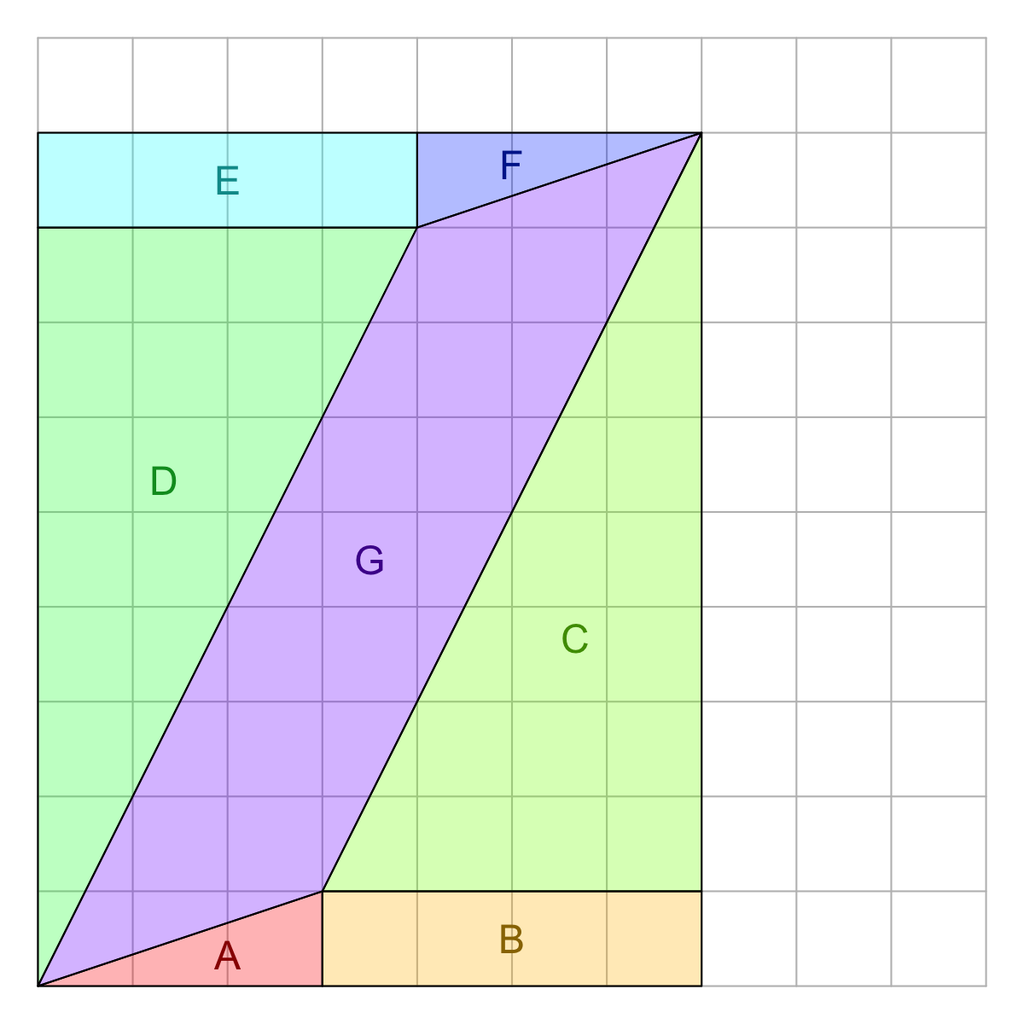

Find the areas of the triangles, rectangles, and parallelogram.

- $A=$
- $B=$
- $C=$
- $D=$
- $E=$
- $F=$
- $G=$
- Remember the area of a rectangle is width times height.
- Remember the area of a triangle is half of base times height.
  - For a right triangle, half the product of the legs.
- To find the area of the parallelogram, you can subtract all 6 other areas from the total area of the rectangle containing all 7 pieces.
- $a=1.5$
- $b=4$
- $c=16$
- $d=16$
- $e=4$
- $f=1.5$
- $g=20$

The figure below shows 7 polygons on a $10\times10$ grid. The grid is composed of 100 squares, each with an area of 1. Each polygon's area is labelled with an uppercase letter from $A$ to $G$.

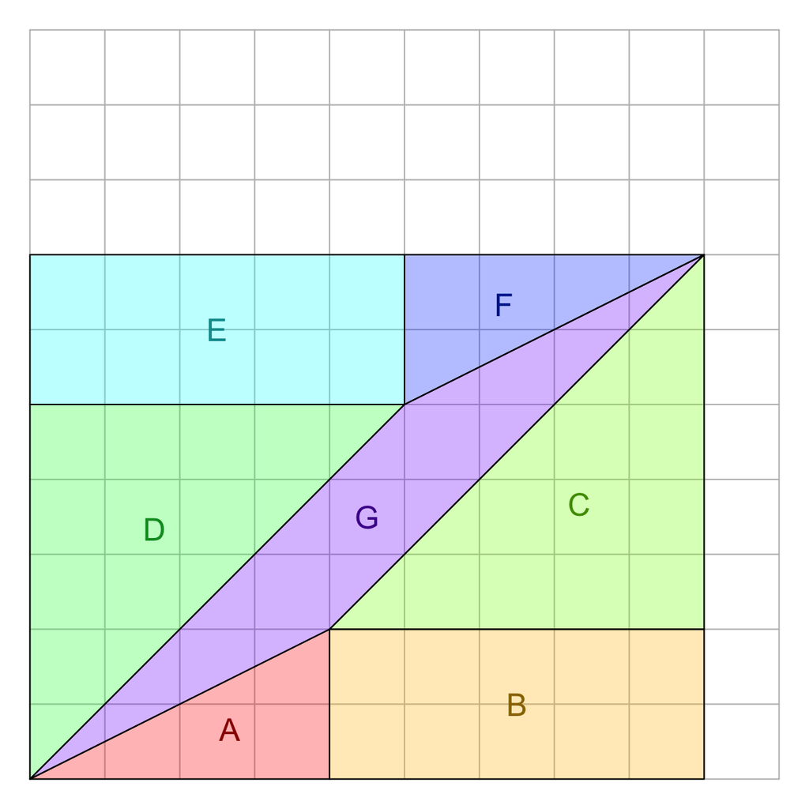

Find the areas of the triangles, rectangles, and parallelogram.

- $A=$
- $B=$
- $C=$
- $D=$
- $E=$
- $F=$
- $G=$
- Remember the area of a rectangle is width times height.
- Remember the area of a triangle is half of base times height.
  - For a right triangle, half the product of the legs.
- To find the area of the parallelogram, you can subtract all 6 other areas from the total area of the rectangle containing all 7 pieces.
- $a=4$
- $b=10$
- $c=12.5$
- $d=12.5$
- $e=10$
- $f=4$
- $g=10$